# R Notebook

Call Libraries

```r
library(tidyverse)
library(janitor)
library(here)
library(readxl)
library(lubridate)
```

```r
# The palette with grey:
cb_palette <- c("#999999", "#E69F00", "#56B4E9", "#009E73", "#F0E442", "#0072B2", "#D55E00", "#CC79A7")

# The palette with black:
# cbb_palette <- c("#000000", "#E69F00", "#56B4E9", "#009E73", "#F0E442", "#0072B2", "#D55E00", "#CC79A7")

# # The palette with all colours:
cbb_palette <- c("#000000", "#999999", "#E69F00", "#56B4E9", "#009E73", "#F0E442", "#0072B2", "#D55E00", "#CC79A7")

# # To use for fills, add
#   scale_fill_manual(values=cbPalette)
#
# # To use for line and point colors, add
#   scale_colour_manual(values=cbPalette)
```

**Overview of GDP in UK and G7 Countries**

International_Labour_Productivity-G7

Load Data

```r
gdp_phw_current <- read_excel(here("raw_data/International_Labour_Productivity-G7.xls"), sheet = "Table 1 R-proc")
gdp_pw_current <- read_excel(here("raw_data/International_Labour_Productivity-G7.xls"), sheet = "Table 2 R-proc")
gdp_phw_const <- read_excel(here("raw_data/International_Labour_Productivity-G7.xls"), sheet = "Table 3 R-proc")
gdp_pw_const <- read_excel(here("raw_data/International_Labour_Productivity-G7.xls"), sheet = "Table 4 R-proc")


glimpse(gdp_phw_current)
```

```
Rows: 22
Columns: 10
$ Year         <dbl> 1995, 1996, 1997, 1998, 1999, 2000, 2001, 2002, 2003, 2004, 2005, 2006, 2007, 2008, 2009, 2010, 2011, 2012, 2013, 2014, 2015, 2016
$ Canada       <dbl> 108.1, 104.0, 104.1, 104.8, 106.2, 101.8, 101.4, 97.5, 97.8, 96.0, 101.3, 99.5, 100.3, 99.2, 101.5, 100.1, 100.6, 99.5, 100.9, 103.7, ~
$ France       <dbl> 124.1, 120.7, 121.6, 124.6, 125.4, 124.7, 126.1, 126.4, 121.9, 117.9, 122.1, 123.6, 125.1, 124.2, 128.0, 127.3, 128.2, 127.4, 131.3, 1~
$ Germany      <dbl> 130.4, 128.3, 127.6, 127.5, 130.8, 126.6, 128.1, 126.6, 127.5, 127.1, 126.1, 122.9, 125.6, 125.4, 127.7, 127.1, 131.4, 132.8, 133.8, 1~
$ Italy        <dbl> 126.2, 121.8, 121.3, 122.4, 120.8, 117.0, 115.3, 110.7, 109.1, 104.6, 105.3, 105.2, 108.1, 109.5, 112.4, 110.7, 111.6, 112.3, 112.5, 1~
$ Japan        <dbl> 90.3, 88.9, 88.1, 88.0, 88.9, 86.7, 86.8, 85.6, 85.5, 85.7, 88.0, 85.7, 87.2, 86.1, 87.3, 87.6, 87.2, 88.4, 89.6, 88.6, 90.9, 92.0
$ UK           <dbl> 100, 100, 100, 100, 100, 100, 100, 100, 100, 100, 100, 100, 100, 100, 100, 100, 100, 100, 100, 100, 100, 100
$ US           <dbl> 123.4, 121.7, 121.3, 123.8, 126.4, 121.3, 122.1, 119.7, 121.3, 121.3, 125.2, 122.1, 124.0, 123.1, 128.8, 128.2, 127.8, 128.2, 127.2, 1~
$ G7           <dbl> 114.5, 112.5, 112.2, 113.8, 115.6, 112.0, 112.5, 110.6, 110.9, 110.3, 113.1, 111.1, 112.8, 112.2, 115.7, 115.2, 115.6, 116.1, 116.3, 1~
$ `G7 exc. UK` <dbl> 115.8, 113.6, 113.3, 115.0, 116.9, 113.1, 113.6, 111.5, 111.9, 111.3, 114.3, 112.1, 114.0, 113.3, 117.2, 116.6, 117.0, 117.6, 117.8, 1~
```

```r
glimpse(gdp_pw_current)
```

```
Rows: 22
Columns: 10
$ Year         <dbl> 1995, 1996, 1997, 1998, 1999, 2000, 2001, 2002, 2003, 2004, 2005, 2006, 2007, 2008, 2009, 2010, 2011, 2012, 2013, 2014, 2015, 2016
$ Canada       <dbl> 110.9, 107.5, 107.3, 108.2, 110.2, 106.5, 105.3, 101.6, 102.0, 100.9, 105.8, 104.0, 104.1, 103.7, 104.6, 103.3, 104.7, 103.1, 103.4, 1~
$ France       <dbl> 115.1, 112.0, 112.1, 114.3, 114.9, 112.6, 112.8, 111.6, 108.1, 106.5, 110.0, 109.9, 111.9, 112.9, 115.4, 115.3, 117.4, 114.7, 116.2, 1~
$ Germany      <dbl> 115.1, 112.0, 110.6, 110.4, 112.8, 108.1, 108.3, 107.5, 108.5, 108.0, 106.4, 105.0, 106.6, 107.1, 106.2, 107.0, 112.0, 110.4, 109.4, 1~
$ Italy        <dbl> 135.4, 131.3, 130.3, 132.9, 131.7, 127.4, 124.3, 120.1, 118.3, 113.4, 114.0, 114.3, 117.2, 119.3, 121.0, 119.2, 121.1, 117.8, 116.2, 1~
$ Japan        <dbl> 98.3, 97.1, 94.9, 93.9, 93.8, 92.8, 92.0, 91.4, 91.9, 91.5, 93.4, 91.6, 92.9, 92.0, 90.6, 92.0, 92.2, 93.3, 93.2, 91.4, 93.3, 94.1
$ UK           <dbl> 100, 100, 100, 100, 100, 100, 100, 100, 100, 100, 100, 100, 100, 100, 100, 100, 100, 100, 100, 100, 100, 100
$ US           <dbl> 131.2, 129.4, 129.3, 132.3, 135.6, 130.9, 129.8, 128.4, 130.2, 130.4, 134.3, 131.5, 132.8, 132.7, 137.5, 137.8, 139.4, 138.3, 136.1, 1~
$ G7           <dbl> 118.1, 116.1, 115.4, 116.9, 118.7, 115.6, 114.7, 113.4, 114.1, 113.5, 116.0, 114.3, 115.7, 115.7, 117.5, 117.7, 119.4, 118.6, 117.5, 1~
$ `G7 exc. UK` <dbl> 119.7, 117.6, 116.8, 118.5, 120.4, 117.0, 116.1, 114.7, 115.4, 114.8, 117.5, 115.7, 117.1, 117.1, 119.1, 119.4, 121.2, 120.3, 119.2, 1~
```

```r
glimpse(gdp_phw_const)
```

```
Rows: 22
Columns: 10
$ Year         <dbl> 1995, 1996, 1997, 1998, 1999, 2000, 2001, 2002, 2003, 2004, 2005, 2006, 2007, 2008, 2009, 2010, 2011, 2012, 2013, 2014, 2015, 2016
$ Canada       <dbl> 85.3, 85.2, 87.2, 88.6, 90.9, 93.5, 94.5, 96.0, 95.8, 96.5, 99.0, 100.0, 100.0, 99.9, 100.6, 102.1, 103.9, 103.6, 105.0, 107.6, 107.6,~
$ France       <dbl> 80.5, 81.4, 83.5, 85.8, 87.6, 91.0, 91.7, 94.5, 95.3, 95.9, 97.3, 100.1, 100.0, 99.3, 98.6, 100.1, 101.3, 101.6, 103.1, 101.7, 102.1, ~
$ Germany      <dbl> 80.8, 82.7, 85.2, 85.9, 88.9, 92.7, 94.7, 96.3, 97.1, 98.4, 98.5, 98.9, 100.0, 100.1, 97.7, 99.8, 103.1, 104.1, 104.5, 105.1, 106.1, 1~
$ Italy        <dbl> 92.7, 92.9, 94.4, 94.3, 94.8, 97.7, 98.2, 97.8, 97.6, 98.1, 99.0, 99.4, 100.0, 98.7, 96.6, 98.9, 99.4, 98.9, 99.6, 99.5, 99.3, 98.4
$ Japan        <dbl> 81.7, 83.5, 84.7, 85.3, 87.3, 89.4, 90.8, 92.7, 94.3, 96.8, 98.6, 99.0, 100.0, 100.0, 99.2, 102.5, 102.8, 103.6, 105.7, 105.7, 107.3, ~
$ UK           <dbl> 78.2, 79.4, 81.3, 83.4, 85.6, 88.4, 89.6, 92.4, 94.0, 95.4, 97.3, 98.9, 100.0, 99.3, 97.7, 99.0, 100.5, 100.0, 100.4, 100.3, 101.1, 10~
$ US           <dbl> 77.9, 79.8, 81.3, 83.7, 86.6, 88.2, 90.1, 92.3, 94.5, 96.9, 98.6, 99.2, 100.0, 100.6, 103.0, 105.6, 106.2, 106.4, 107.2, 108.0, 109.2,~
$ G7           <dbl> 79.9, 81.4, 83.1, 85.0, 87.5, 89.8, 91.4, 93.3, 94.8, 96.8, 98.4, 99.2, 100.0, 100.1, 100.6, 102.9, 104.0, 104.3, 105.3, 105.8, 106.9,~
$ `G7 exc. UK` <dbl> 80.0, 81.6, 83.3, 85.1, 87.6, 89.9, 91.5, 93.4, 94.9, 96.9, 98.5, 99.2, 100.0, 100.2, 100.9, 103.3, 104.3, 104.7, 105.8, 106.4, 107.5,~
```

```r
glimpse(gdp_pw_const)
```

```
Rows: 22
Columns: 10
$ Year         <dbl> 1995, 1996, 1997, 1998, 1999, 2000, 2001, 2002, 2003, 2004, 2005, 2006, 2007, 2008, 2009, 2010, 2011, 2012, 2013, 2014, 2015, 2016
$ Canada       <dbl> 87.0, 87.6, 89.5, 90.7, 93.0, 95.5, 96.1, 96.7, 96.1, 97.5, 99.3, 100.2, 100.0, 99.6, 98.3, 99.9, 101.5, 102.0, 103.0, 105.3, 105.5, 1~
$ France       <dbl> 86.2, 87.2, 88.8, 90.5, 91.8, 93.1, 93.3, 93.6, 94.3, 96.8, 97.7, 99.0, 100.0, 99.7, 97.9, 99.7, 101.0, 100.9, 101.3, 99.9, 100.9, 101~
$ Germany      <dbl> 86.7, 87.7, 89.7, 90.1, 92.3, 94.6, 95.9, 96.8, 97.1, 98.3, 97.6, 99.0, 100.0, 99.6, 94.2, 97.4, 100.8, 100.5, 99.9, 101.0, 101.9, 101~
$ Italy        <dbl> 94.6, 95.3, 96.6, 97.2, 97.6, 99.5, 99.3, 98.2, 97.4, 98.0, 98.7, 99.1, 100.0, 98.1, 94.3, 96.7, 96.9, 94.3, 94.2, 94.0, 94.1, 93.7
$ Japan        <dbl> 86.2, 88.5, 88.4, 88.0, 88.5, 91.2, 92.1, 93.4, 95.0, 96.9, 98.1, 99.0, 100.0, 99.2, 95.2, 99.5, 99.5, 101.3, 102.6, 102.4, 103.4, 103~
$ UK           <dbl> 80.7, 82.0, 84.0, 85.8, 87.6, 89.6, 91.1, 92.8, 93.8, 95.2, 97.0, 98.4, 100.0, 98.2, 96.1, 97.4, 98.0, 98.7, 99.8, 100.3, 101.0, 101.5
$ US           <dbl> 79.8, 81.7, 83.5, 86.0, 88.7, 90.1, 90.9, 92.8, 94.6, 97.1, 98.6, 99.3, 100.0, 100.2, 101.1, 104.3, 105.4, 105.7, 106.4, 107.4, 108.6,~
$ G7           <dbl> 83.0, 84.6, 86.1, 87.7, 89.7, 91.6, 92.4, 93.8, 94.9, 97.0, 98.2, 99.2, 100.0, 99.6, 98.1, 101.0, 102.1, 102.5, 103.2, 103.8, 104.8, 1~
$ `G7 exc. UK` <dbl> 83.1, 84.8, 86.3, 87.8, 89.8, 91.7, 92.5, 93.8, 95.0, 97.1, 98.3, 99.2, 100.0, 99.7, 98.3, 101.3, 102.5, 102.9, 103.5, 104.1, 105.2, 1~
```

Change Year in datetime format

```r
gdp_phw_current <- gdp_phw_current %>%
  mutate(Year = make_datetime(Year))

gdp_pw_current <- gdp_pw_current %>%
  mutate(Year = make_datetime(Year))

gdp_phw_const <- gdp_phw_const %>%
  mutate(Year = make_datetime(Year))

gdp_pw_const <- gdp_pw_const %>%
  mutate(Year = make_datetime(Year))
```

Check for NA values

```r
gdp_phw_current %>%
  summarise(across(.cols = everything(),
                   .fns = ~sum(is.na(.x))))
```

| Year | Canada | France | Germany | Italy | Japan | UK | US | G7 | G7 exc. UK |
| --- | --- | --- | --- | --- | --- | --- | --- | --- | --- |
| 0 | 0 | 0 | 0 | 0 | 0 | 0 | 0 | 0 | 0 |

```r
gdp_pw_current %>%
  summarise(across(.cols = everything(),
                   .fns = ~sum(is.na(.x))))
```

| Year | Canada | France | Germany | Italy | Japan | UK | US | G7 | G7 exc. UK |
| --- | --- | --- | --- | --- | --- | --- | --- | --- | --- |
| 0 | 0 | 0 | 0 | 0 | 0 | 0 | 0 | 0 | 0 |

```r
gdp_phw_const %>%
  summarise(across(.cols = everything(),
                   .fns = ~sum(is.na(.x))))
```

| Year | Canada | France | Germany | Italy | Japan | UK | US | G7 | G7 exc. UK |
| --- | --- | --- | --- | --- | --- | --- | --- | --- | --- |
| 0 | 0 | 0 | 0 | 0 | 0 | 0 | 0 | 0 | 0 |

```r
gdp_pw_const %>%
  summarise(across(.cols = everything(),
                   .fns = ~sum(is.na(.x))))
```

| Year | Canada | France | Germany | Italy | Japan | UK | US | G7 | G7 exc. UK |
| --- | --- | --- | --- | --- | --- | --- | --- | --- | --- |
| 0 | 0 | 0 | 0 | 0 | 0 | 0 | 0 | 0 | 0 |

Pivot data to long format

```r
tidy_gdp_phw_current <- gdp_phw_current %>%
  pivot_longer(-Year, names_to = "Country", values_to = "GDP_phw") %>%
  relocate(Year, .after = Country)

tidy_gdp_pw_current <- gdp_pw_current %>%
  pivot_longer(-Year, names_to = "Country", values_to = "GDP_pw") %>%
  relocate(Year, .after = Country)

tidy_gdp_phw_const <- gdp_phw_const %>%
  pivot_longer(-Year, names_to = "Country", values_to = "GDP_phw") %>%
  relocate(Year, .after = Country)

tidy_gdp_pw_const <- gdp_pw_const %>%
  pivot_longer(-Year, names_to = "Country", values_to = "GDP_pw") %>%
  relocate(Year, .after = Country)



tidy_gdp_phw_current
```

| Country | Year | GDP_phw |
| --- | --- | --- |
| Canada | 1995-01-01 | 108.1 |
| France | 1995-01-01 | 124.1 |
| Germany | 1995-01-01 | 130.4 |
| Italy | 1995-01-01 | 126.2 |
| Japan | 1995-01-01 | 90.3 |
| UK | 1995-01-01 | 100.0 |
| US | 1995-01-01 | 123.4 |
| G7 | 1995-01-01 | 114.5 |
| G7 exc. UK | 1995-01-01 | 115.8 |
| Canada | 1996-01-01 | 104.0 |

[output cut: 188 more lines]

```r
tidy_gdp_pw_current
```

| Country | Year | GDP_pw |
| --- | --- | --- |
| Canada | 1995-01-01 | 110.9 |
| France | 1995-01-01 | 115.1 |
| Germany | 1995-01-01 | 115.1 |
| Italy | 1995-01-01 | 135.4 |
| Japan | 1995-01-01 | 98.3 |
| UK | 1995-01-01 | 100.0 |
| US | 1995-01-01 | 131.2 |
| G7 | 1995-01-01 | 118.1 |
| G7 exc. UK | 1995-01-01 | 119.7 |
| Canada | 1996-01-01 | 107.5 |

[output cut: 188 more lines]

```r
tidy_gdp_phw_const
```

| Country | Year | GDP_phw |
| --- | --- | --- |
| Canada | 1995-01-01 | 85.3 |
| France | 1995-01-01 | 80.5 |
| Germany | 1995-01-01 | 80.8 |
| Italy | 1995-01-01 | 92.7 |
| Japan | 1995-01-01 | 81.7 |
| UK | 1995-01-01 | 78.2 |
| US | 1995-01-01 | 77.9 |
| G7 | 1995-01-01 | 79.9 |
| G7 exc. UK | 1995-01-01 | 80.0 |
| Canada | 1996-01-01 | 85.2 |

[output cut: 188 more lines]

```r
tidy_gdp_pw_const
```

| Country | Year | GDP_pw |
| --- | --- | --- |
| Canada | 1995-01-01 | 87.0 |
| France | 1995-01-01 | 86.2 |
| Germany | 1995-01-01 | 86.7 |
| Italy | 1995-01-01 | 94.6 |
| Japan | 1995-01-01 | 86.2 |
| UK | 1995-01-01 | 80.7 |
| US | 1995-01-01 | 79.8 |
| G7 | 1995-01-01 | 83.0 |
| G7 exc. UK | 1995-01-01 | 83.1 |
| Canada | 1996-01-01 | 87.6 |

[output cut: 188 more lines]

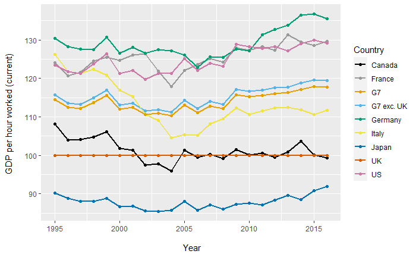

```r
tidy_gdp_phw_current %>%
  ggplot() +
  aes(x = Year, y = GDP_phw, colour = Country) +
  geom_line(size = 0.75) +
  geom_point(size = 1.5) +
  # scale_colour_brewer(palette = "Dark2")
  scale_colour_manual(values = cbb_palette) +
  labs(
    x = "\n Year",
    y = "GDP per hour worked (current) \n"
  )
```

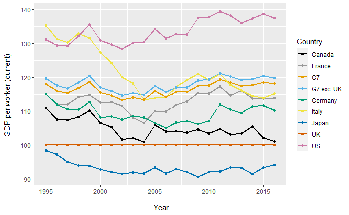

```r
tidy_gdp_pw_current %>%
  ggplot() +
  aes(x = Year, y = GDP_pw, colour = Country) +
  geom_line(size = 0.75) +
  geom_point(size = 1.5) +
  # scale_colour_brewer(palette = "Dark2")
  scale_colour_manual(values = cbb_palette) +
  labs(
    x = "\n Year",
    y = "GDP per worker (current) \n"
  )
```

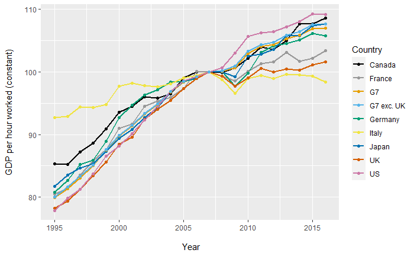

```r
tidy_gdp_phw_const %>%
  ggplot() +
  aes(x = Year, y = GDP_phw, colour = Country) +
  geom_line(size = 0.75) +
  geom_point(size = 1.5) +
  # scale_colour_brewer(palette = "Dark2")
  scale_colour_manual(values = cbb_palette) +
  labs(
    x = "\n Year",
    y = "GDP per hour worked (constant)\n"
  )
```

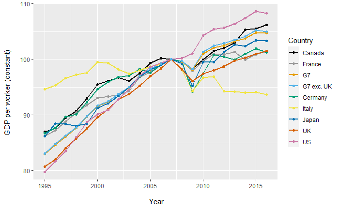

```r
tidy_gdp_pw_const %>%
  ggplot() +
  aes(x = Year, y = GDP_pw, colour = Country) +
  geom_line(size = 0.75) +
  geom_point(size = 1.5) +
  # scale_colour_brewer(palette = "Dark2")
  scale_colour_manual(values = cbb_palette) +
  labs(
    x = "\n Year",
    y = "GDP per worker (constant) \n"
  )
```

Labour_Productivity-OECD_Countries

Read data

```r
gdp_phw_OECD <- read_csv(here("raw_data/Labour_Productivity-OECD_Countries.csv"))
glimpse(gdp_phw_OECD)
```

```
Rows: 3,402
Columns: 8
$ LOCATION     <chr> "AUS", "AUS", "AUS", "AUS", "AUS", "AUS", "AUS", "AUS", "AUS", "AUS", "AUS", "AUS", "AUS", "AUS", "AUS", "AUS", "AUS", "AUS", "AUS", "~
$ INDICATOR    <chr> "GDPHRWKD", "GDPHRWKD", "GDPHRWKD", "GDPHRWKD", "GDPHRWKD", "GDPHRWKD", "GDPHRWKD", "GDPHRWKD", "GDPHRWKD", "GDPHRWKD", "GDPHRWKD", "G~
$ SUBJECT      <chr> "TOT", "TOT", "TOT", "TOT", "TOT", "TOT", "TOT", "TOT", "TOT", "TOT", "TOT", "TOT", "TOT", "TOT", "TOT", "TOT", "TOT", "TOT", "TOT", "~
$ MEASURE      <chr> "USD", "USD", "USD", "USD", "USD", "USD", "USD", "USD", "USD", "USD", "USD", "USD", "USD", "USD", "USD", "USD", "USD", "USD", "USD", "~
$ FREQUENCY    <chr> "A", "A", "A", "A", "A", "A", "A", "A", "A", "A", "A", "A", "A", "A", "A", "A", "A", "A", "A", "A", "A", "A", "A", "A", "A", "A", "A",~
$ TIME         <dbl> 1970, 1971, 1972, 1973, 1974, 1975, 1976, 1977, 1978, 1979, 1980, 1981, 1982, 1983, 1984, 1985, 1986, 1987, 1988, 1989, 1990, 1991, 19~
$ Value        <dbl> 26.78308, 27.45255, 28.05676, 28.63459, 28.17890, 29.22191, 29.70971, 29.67610, 30.92820, 31.07815, 31.41144, 32.33939, 32.74383, 33.5~
$ `Flag Codes` <chr> NA, NA, NA, NA, NA, NA, NA, NA, NA, NA, NA, NA, NA, NA, NA, NA, NA, NA, NA, NA, NA, NA, NA, NA, NA, NA, NA, NA, NA, NA, NA, NA, NA, NA~
```

Change TIME in datetime format

```r
gdp_phw_OECD <- gdp_phw_OECD %>%
  mutate(TIME = make_datetime(TIME))
```

Check for NA values

```r
gdp_phw_OECD %>%
  summarise(across(.cols = everything(),
                   .fns = ~sum(is.na(.x))))
```

| LOCATION | INDICATOR | SUBJECT | MEASURE | FREQUENCY | TIME | Value | Flag Codes |
| --- | --- | --- | --- | --- | --- | --- | --- |
| 0 | 0 | 0 | 0 | 0 | 0 | 0 | 3350 |

```r
gdp_phw_OECD %>%
  distinct(LOCATION)
```

| LOCATION |
| --- |
| AUS |
| AUT |
| BEL |
| CAN |
| CZE |
| DNK |
| FIN |
| FRA |
| DEU |
| GRC |

[output cut: 37 more lines]

```r
  # distinct(SUBJECT) # TOT
  # distinct(MEASURE) # USD IDX2010
  # distinct(FREQUENCY) #A
  # distinct(`Flag Codes`) # NA B E
```

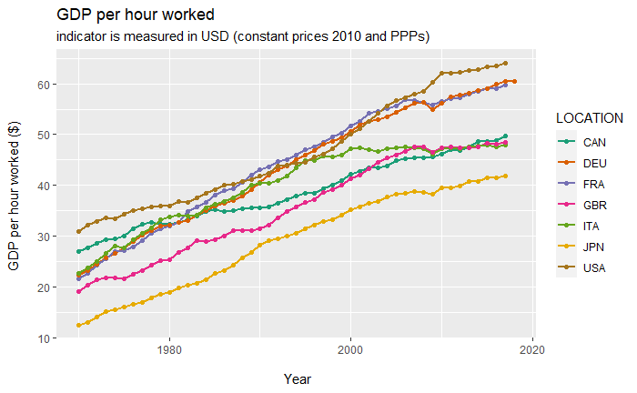

```r
gdp_phw_OECD %>%
  select(-c(`Flag Codes`, INDICATOR, FREQUENCY, SUBJECT)) %>%
  filter(
    # LOCATION %in% c("G-7", "EU28", "CAN", "FRA", "DEU", "ITA", "JPN", "USA", "GBR"),
    LOCATION %in% c("CAN", "FRA", "DEU", "ITA", "JPN", "USA", "GBR"),
    # LOCATION %in% c("G-7", "EU28", "GBR"),
    MEASURE == "USD") %>%
  ggplot() +
  aes(x = TIME, y = Value, colour = LOCATION) +
  geom_line(size = 0.75) +
  geom_point(size = 1.5) +
  scale_colour_brewer(palette = "Dark2") +
  # scale_colour_manual(values = cbb_palette) +
  ggtitle(
    "GDP per hour worked",
    subtitle =  "indicator is measured in USD (constant prices 2010 and PPPs)"
  ) +
  labs(
    x = "\n Year",
    y = "GDP per hour worked ($) \n"
  )
```

```r
NA
```

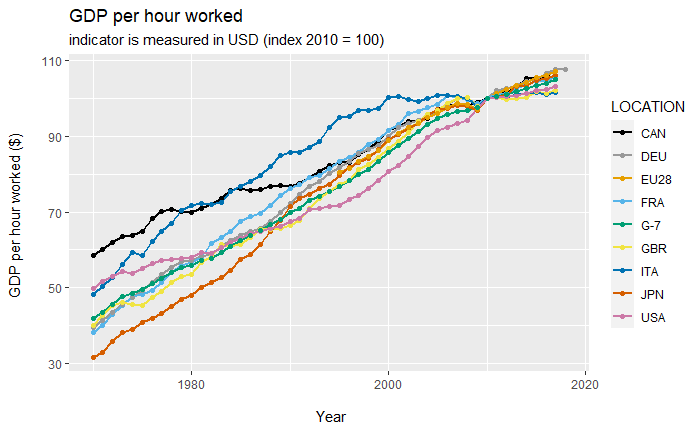

```r
gdp_phw_OECD %>%
  select(-c(`Flag Codes`, INDICATOR, FREQUENCY, SUBJECT)) %>%
  filter(LOCATION %in% c("G-7", "EU28", "CAN", "FRA", "DEU", "ITA", "JPN", "USA", "GBR"),
         MEASURE == "IDX2010") %>%
  ggplot() +
  aes(x = TIME, y = Value, colour = LOCATION) +
  geom_line(size = 0.75) +
  geom_point(size = 1.5) +
  # scale_colour_brewer(palette = "Dark2")
  scale_colour_manual(values = cbb_palette) +
  ggtitle(
    "GDP per hour worked",
    subtitle =  "indicator is measured in USD (index 2010 = 100)"
  ) +
  labs(
    x = "\n Year",
    y = "GDP per hour worked ($) \n"
  )
```

```r
NA
```

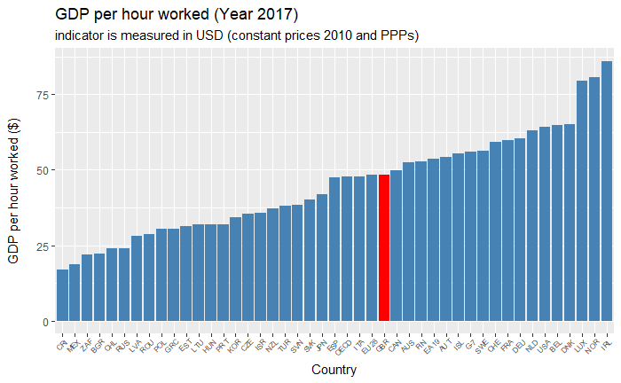

```r
gdp_phw_OECD %>%
  mutate(TIME = year(TIME)) %>%
  filter(
    # LOCATION %in% c("G-7", "EU28", "CAN", "FRA", "DEU", "ITA", "JPN", "USA", "GBR"),
    MEASURE == "USD",
    TIME == 2017
    ) %>%
  select(-c(`Flag Codes`, INDICATOR, FREQUENCY, SUBJECT, MEASURE, TIME)) %>%
  ggplot() +
  aes(
    x = reorder(LOCATION, Value),
    y = Value,
    fill = reorder(LOCATION, Value) == "GBR"
    ) +
  geom_col() +
  scale_fill_manual(values = c('steelblue', 'red'), guide = "none") +
  theme(
    axis.text.x = element_text(size = 6, angle = 45, vjust = 1.15, hjust = 1) ) +
  ggtitle(
    "GDP per hour worked (Year 2017)",
    subtitle =  "indicator is measured in USD (constant prices 2010 and PPPs)"
  ) +
  labs(
    x = "Country",
    y = "GDP per hour worked ($)\n"
  )
```

```r
NA
```

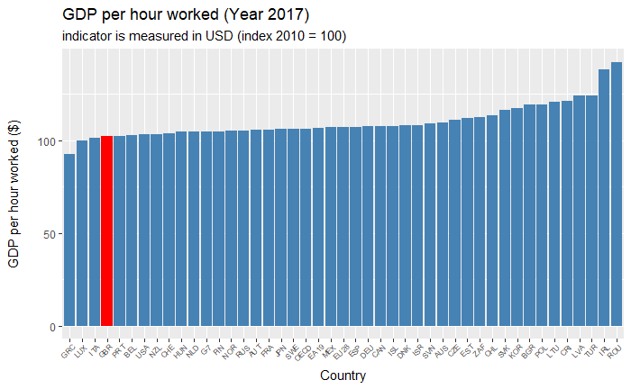

```r
gdp_phw_OECD %>%
  mutate(TIME = year(TIME)) %>%
  filter(
    # LOCATION %in% c("G-7", "EU28", "CAN", "FRA", "DEU", "ITA", "JPN", "USA", "GBR"),
    MEASURE == "IDX2010",
    TIME == 2017
    ) %>%
  select(-c(`Flag Codes`, INDICATOR, FREQUENCY, SUBJECT, MEASURE, TIME)) %>%
  ggplot() +
  aes(
    x = reorder(LOCATION, Value),
    y = Value,
    fill = reorder(LOCATION, Value) == "GBR"
    ) +
  geom_col() +
  scale_fill_manual(values = c('steelblue', 'red'), guide = "none") +
  theme(
    axis.text.x = element_text(size = 6, angle = 45, vjust = 1.15, hjust = 1)
    ) +
  ggtitle(
    "GDP per hour worked (Year 2017)",
    subtitle =  "indicator is measured in USD (index 2010 = 100)"
  ) +
  labs(
    x = "Country",
    y = "GDP per hour worked ($)\n"
  )
```

**Compare productivity by industry in UK and EU Countries**

Load Data

```r
productivity_phw <- read_excel(here("raw_data/International_Labour_Productivity-Europe.xls"), sheet = "Table 1 R-proc")
productivity_growth <- read_excel(here("raw_data/International_Labour_Productivity-Europe.xls"), sheet = "Table 2 R-proc")


glimpse(productivity_phw)
```

```
Rows: 9
Columns: 31
$ `A*10 (excl L)`  <chr> "A", "B-E", "F", "G-I", "J", "K", "M-N", "O-Q", "R-U"
$ `NACE Industry`  <chr> "Agriculture, forestry and fishing", "Industry (except construction)", "Construction", "Wholesale and retail trade, transport, acc~
$ Belgium          <dbl> 25.66616, 60.19409, 38.87564, 41.93782, 59.65125, 88.10338, 24.53516, 28.17312, 19.69698
$ Bulgaria         <dbl> 2.600904, 12.304376, 9.656289, 8.787120, 29.345819, 63.410313, 14.696489, 20.903489, 18.492694
$ `Czech Republic` <dbl> 14.05971, 23.72004, 13.17658, 15.50173, 40.03371, 59.11678, 19.91482, 25.96555, 17.04386
$ Denmark          <dbl> 31.74844, 68.35846, 24.29677, 34.50571, 46.87635, 72.01052, 26.97661, 24.77941, 22.36061
$ Germany          <dbl> 19.49727, 52.43710, 20.68757, 29.74980, 60.08252, 51.46037, 31.99290, 27.90071, 22.09946
$ Estonia          <dbl> 16.88883, 17.08604, 13.67928, 14.98199, 31.06519, 57.22183, 24.90567, 15.93756, 10.01729
$ Ireland          <dbl> 9.591133, 72.697607, 25.150283, 25.012769, 100.300137, 62.397006, 36.499863, 22.530640, 17.449500
$ Greece           <dbl> 5.210345, 27.074545, 15.911999, 13.549916, 27.128820, 49.926840, 12.507425, 25.603642, 12.489497
$ Spain            <dbl> 19.88720, 44.38977, 34.85822, 23.12436, 43.96195, 55.78498, 19.17254, 24.39174, 14.69544
$ France           <dbl> 18.03665, 47.50529, 24.92221, 32.25440, 62.20943, 53.23991, 31.13475, 29.20290, 18.40162
$ Croatia          <dbl> 6.929569, 14.181170, 14.690133, 11.301189, 27.066587, 56.951325, 26.218405, 15.802399, 17.817717
```

[output cut: 18 more lines]

```r
glimpse(productivity_growth)
```

```
Rows: 9
Columns: 29
$ `A*10 (excl L)`  <chr> "A", "B-E", "F", "G-I", "J", "K", "M-N", "O-Q", "R-U"
$ `NACE Industry`  <chr> "Agriculture, forestry and fishing", "Industry (except construction)", "Construction", "Wholesale and retail trade, transport, acc~
$ Bulgaria         <dbl> 0.03762024, 0.04306486, 0.01968665, 0.07392434, -0.08274970, -0.02440974, 0.04568291, 0.01949288, -0.02800381
$ `Czech Republic` <dbl> 0.15523012, 0.04230038, 0.03184858, 0.04930588, 0.07100998, 0.17305095, 0.04829006, 0.00411687, 0.01648911
$ Denmark          <dbl> 0.09561540, 0.01081644, 0.01146514, -0.02340411, 0.11628837, -0.10960605, 0.01762140, 0.01010562, 0.01446469
$ Germany          <dbl> 0.207427124, 0.041322490, 0.019115609, 0.021288599, 0.025971707, 0.029641791, -0.003529125, 0.005855962, 0.015685401
$ Estonia          <dbl> -0.21282514, -0.03410064, 0.03195887, 0.01055122, -0.08222485, -0.21902659, 0.02644456, 0.05304766, -0.05042502
$ Ireland          <dbl> 0.149116937, 0.753785373, 0.009196466, 0.071386415, 0.168403154, 0.114763465, 0.316017336, 0.027947060, -0.002288232
$ Greece           <dbl> -0.0363313989, 0.0009277398, -0.0067258433, -0.0498922663, -0.0958815588, 0.0005509581, -0.0752025048, -0.0365579797, 0.0425457757
$ Spain            <dbl> 0.007651545, 0.028572102, -0.047825854, 0.026538370, -0.023294791, -0.055613456, 0.034704412, 0.013199765, -0.010159202
$ France           <dbl> -0.073544029, 0.045800398, 0.018924530, 0.027709269, 0.031334875, -0.025443408, -0.015632316, 0.009189933, 0.023611436
$ Croatia          <dbl> 0.22078574, 0.11458163, -0.04157474, 0.17401630, -0.16943833, -0.01810939, -0.16417076, 0.08328010, -0.17354945
$ Italy            <dbl> 0.013393880, 0.012490617, 0.021676441, -0.004523443, -0.002343728, -0.034086473, -0.029787546, -0.024783609, -0.009893064
```

[output cut: 16 more lines]

Check for NA values

```r
productivity_phw %>%
  summarise(across(.cols = everything(),
                   .fns = ~sum(is.na(.x))))
```

| A*10 (excl L) | NACE Industry | Belgium | Bulgaria | Czech Republic | Denmark | Germany | Estonia | Ireland | Greece | Spain | France | Croatia | Italy | Cyprus | Latvia | Lithuania | Luxembourg | Hungary | Netherlands | Austria | Poland | Portugal | Romania | Slovenia | Slovakia | Finland | Sweden | United Kingdom | Norway | … |
| --- | --- | --- | --- | --- | --- | --- | --- | --- | --- | --- | --- | --- | --- | --- | --- | --- | --- | --- | --- | --- | --- | --- | --- | --- | --- | --- | --- | --- | --- | --- |
| 0 | 0 | 0 | 0 | 0 | 0 | 0 | 0 | 0 | 0 | 0 | 0 | 0 | 0 | 0 | 0 | 0 | 0 | 0 | 0 | 0 | 0 | 0 | 0 | 0 | 0 | 0 | 0 | 0 | 0 | … |

```r
productivity_growth %>%
  summarise(across(.cols = everything(),
                   .fns = ~sum(is.na(.x))))
```

| A*10 (excl L) | NACE Industry | Bulgaria | Czech Republic | Denmark | Germany | Estonia | Ireland | Greece | Spain | France | Croatia | Italy | Cyprus | Latvia | Lithuania | Luxembourg | Hungary | Netherlands | Austria | Poland | Portugal | Romania | Slovenia | Slovakia | Finland | Sweden | United Kingdom | Norway |
| --- | --- | --- | --- | --- | --- | --- | --- | --- | --- | --- | --- | --- | --- | --- | --- | --- | --- | --- | --- | --- | --- | --- | --- | --- | --- | --- | --- | --- |
| 0 | 0 | 0 | 0 | 0 | 0 | 0 | 0 | 0 | 0 | 0 | 0 | 0 | 0 | 0 | 0 | 0 | 0 | 0 | 0 | 0 | 0 | 0 | 0 | 0 | 0 | 0 | 0 | 0 |

Pivot data to long format

```r
tidy_productivity_phw <- productivity_phw %>%
  pivot_longer(-c(`A*10 (excl L)`, `NACE Industry`), names_to = "Country", values_to = "Output_per_hour")

tidy_productivity_growth <- productivity_growth %>%
  pivot_longer(-c(`A*10 (excl L)`, `NACE Industry`), names_to = "Country", values_to = "Labour_Productivity_Growth")


tidy_productivity_phw
```

| A*10 (excl L) | NACE Industry | Country | Output_per_hour |
| --- | --- | --- | --- |
| A | Agriculture, forestry and fishing | Belgium | 25.666164 |
| A | Agriculture, forestry and fishing | Bulgaria | 2.600904 |
| A | Agriculture, forestry and fishing | Czech Republic | 14.059709 |
| A | Agriculture, forestry and fishing | Denmark | 31.748444 |
| A | Agriculture, forestry and fishing | Germany | 19.497269 |
| A | Agriculture, forestry and fishing | Estonia | 16.888828 |
| A | Agriculture, forestry and fishing | Ireland | 9.591133 |
| A | Agriculture, forestry and fishing | Greece | 5.210345 |
| A | Agriculture, forestry and fishing | Spain | 19.887198 |
| A | Agriculture, forestry and fishing | France | 18.036654 |

[output cut: 251 more lines]

```r
tidy_productivity_growth
```

| A*10 (excl L) | NACE Industry | Country | Labour_Productivity_Growth |
| --- | --- | --- | --- |
| A | Agriculture, forestry and fishing | Bulgaria | 3.762024e-02 |
| A | Agriculture, forestry and fishing | Czech Republic | 1.552301e-01 |
| A | Agriculture, forestry and fishing | Denmark | 9.561540e-02 |
| A | Agriculture, forestry and fishing | Germany | 2.074271e-01 |
| A | Agriculture, forestry and fishing | Estonia | -2.128251e-01 |
| A | Agriculture, forestry and fishing | Ireland | 1.491169e-01 |
| A | Agriculture, forestry and fishing | Greece | -3.633140e-02 |
| A | Agriculture, forestry and fishing | Spain | 7.651545e-03 |
| A | Agriculture, forestry and fishing | France | -7.354403e-02 |
| A | Agriculture, forestry and fishing | Croatia | 2.207857e-01 |

[output cut: 233 more lines]

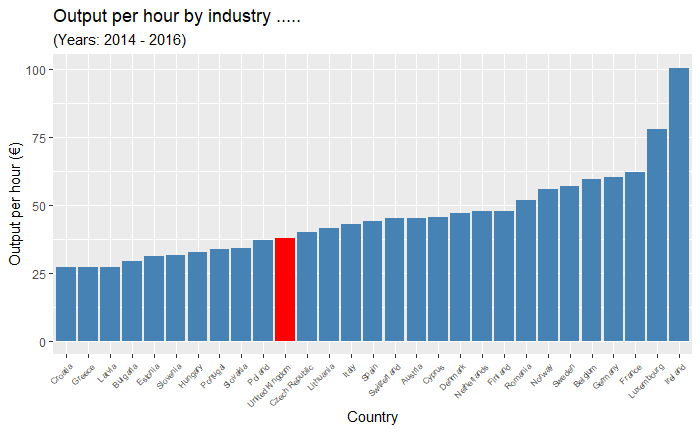

```r
tidy_productivity_phw %>%
  filter(
    # `NACE Industry` == "Agriculture, forestry and fishing"
    # `NACE Industry` == "Industry (except construction)"
    # `NACE Industry` == "Construction"
    # `NACE Industry` == "Wholesale and retail trade, transport, accommodation and food service activities"
    `NACE Industry` == "Information and communication"
    # `NACE Industry` == "Financial and insurance activities"
    # `NACE Industry` == "Professional, scientific and technical activities; administrative and support service activities"
    # `NACE Industry` == "Public administration, defence, education, human health and social work activities"
    # `NACE Industry` == "Arts, entertainment and recreation; other service activities"
  ) %>%
  ggplot() +
  aes(
    x = reorder(Country, Output_per_hour),
    y = Output_per_hour,
    fill = reorder(Country, Output_per_hour) == "United Kingdom"
    ) +
  geom_col() +
  scale_fill_manual(values = c('steelblue', 'red'), guide = "none") +
  theme(
    axis.text.x = element_text(size = 6, angle = 45, vjust = 1, hjust = 1)
  ) +
  ggtitle(
    "Output per hour by industry .....",
    subtitle =  "(Years: 2014 - 2016)"
  ) +
  labs(
    x = "Country",
    y = "Output per hour (€)"
  )
```

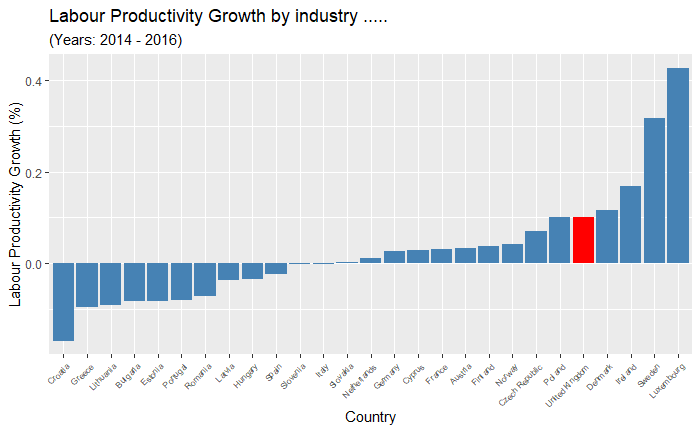

```r
tidy_productivity_growth %>%
  filter(
    # `NACE Industry` == "Agriculture, forestry and fishing"
    # `NACE Industry` == "Industry (except construction)"
    # `NACE Industry` == "Construction"
    # `NACE Industry` == "Wholesale and retail trade, transport, accommodation and food service activities"
    `NACE Industry` == "Information and communication"
    # `NACE Industry` == "Financial and insurance activities"
    # `NACE Industry` == "Professional, scientific and technical activities; administrative and support service activities"
    # `NACE Industry` == "Public administration, defence, education, human health and social work activities"
    # `NACE Industry` == "Arts, entertainment and recreation; other service activities"
  ) %>%
  ggplot() +
  aes(
    x = reorder(Country, Labour_Productivity_Growth),
    y = Labour_Productivity_Growth,
    fill = reorder(Country, Labour_Productivity_Growth) == "United Kingdom"
    ) +
  geom_col() +
  scale_fill_manual(values = c('steelblue', 'red'), guide = "none") +
  theme(
    axis.text.x = element_text(size = 6,angle = 45, vjust = 1, hjust = 1)
    ) +
  ggtitle(
    "Labour Productivity Growth by industry ..... ",
    subtitle =  "(Years: 2014 - 2016)"
  ) +
  labs(
    x = "Country",
    y = "Labour Productivity Growth (%)"
  )
```

Comparison with large economies in Europe: UK, France, Germany, Italy, Spain (the Netherlands)

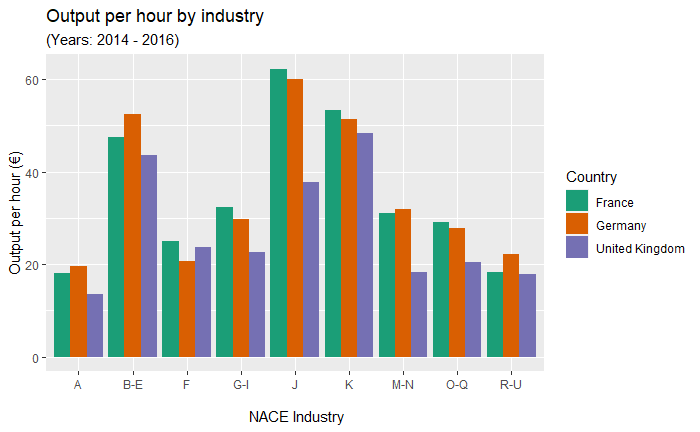

```r
tidy_productivity_phw %>%
  filter(
    Country %in% c("United Kingdom", "France", "Germany")
  ) %>%
  ggplot() +
  aes(
    x = `A*10 (excl L)`,
    y = Output_per_hour,
    fill = Country
    ) +
  geom_col(position = "dodge") +
  scale_fill_brewer(palette = "Dark2") +
  ggtitle(
    "Output per hour by industry",
    subtitle =  "(Years: 2014 - 2016)"
  ) +
  labs(
    x = "\n NACE Industry",
    y = "Output per hour (€)"
  )
```

```r
tidy_productivity_phw %>%
  distinct(`A*10 (excl L)`, `NACE Industry`)
```

| A*10 (excl L) | NACE Industry |
| --- | --- |
| A | Agriculture, forestry and fishing |
| B-E | Industry (except construction) |
| F | Construction |
| G-I | Wholesale and retail trade, transport, accommodation and food service activities |
| J | Information and communication |
| K | Financial and insurance activities |
| M-N | Professional, scientific and technical activities; administrative and support service activities |
| O-Q | Public administration, defence, education, human health and social work activities |
| R-U | Arts, entertainment and recreation; other service activities |

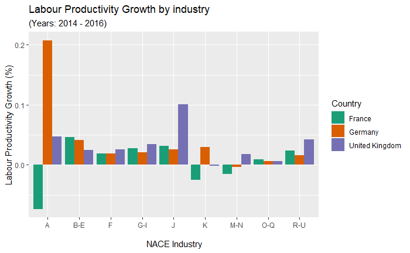

```r
tidy_productivity_growth %>%
  filter(
    Country %in% c("United Kingdom", "France", "Germany")
  ) %>%
  ggplot() +
  aes(
    x = `A*10 (excl L)`,
    y = Labour_Productivity_Growth,
    fill = Country
    ) +
  geom_col(position = "dodge") +
  scale_fill_brewer(palette = "Dark2") +
  ggtitle(
    "Labour Productivity Growth by industry",
    subtitle =  "(Years: 2014 - 2016)"
  ) +
  labs(
    x = "\n NACE Industry",
    y = "Labour Productivity Growth (%)"
  )
```

Comparison with most productive countries in Europe (2017): UK, Ireland, Norway

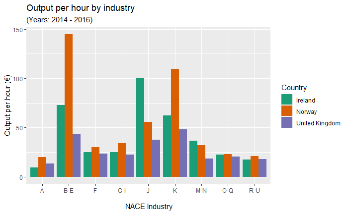

```r
tidy_productivity_phw %>%
  filter(
    Country %in% c("United Kingdom", "Ireland", "Norway")
  ) %>%
  ggplot() +
  aes(
    x = `A*10 (excl L)`,
    y = Output_per_hour,
    fill = Country
    ) +
  geom_col(position = "dodge") +
  scale_fill_brewer(palette = "Dark2") +
  ggtitle(
    "Output per hour by industry",
    subtitle =  "(Years: 2014 - 2016)"
  ) +
  labs(
    x = "\n NACE Industry",
    y = "Output per hour (€)"
  )
```

Comparison with large economies in Europe: UK, France, Germany, Italy, Spain (the Netherlands) Output per hour by industry 2014-16

```r
productivity_phw %>%
  select(France, `United Kingdom`, Germany, Spain, Italy) %>%
  summarise(
    sum_France = sum(France),
    sum_UK = sum(`United Kingdom`),
    sum_Germany = sum(Germany),
    sum_Spain = sum(Spain),
    sum_Italy = sum(Italy)
  )
```

| sum_France | sum_UK | sum_Germany | sum_Spain | sum_Italy |
| --- | --- | --- | --- | --- |
| 316.9072 | 246.4642 | 315.9077 | 280.2662 | 265.5573 |

```r
NA
```

France has a similar GDP with the UK for the past years and the population is similar, hence it is ideal for making one-to-one comparisons. Overall, France is doing better than the UK in terms of productivity (GDP per hrs worked or GDP per worker)

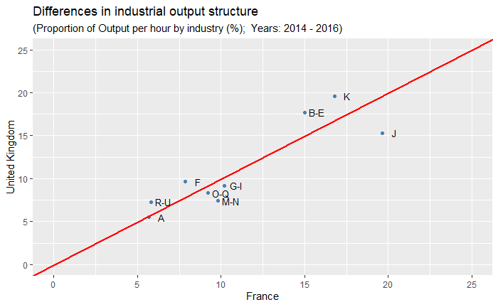

```r
productivity_phw %>%
  select(`A*10 (excl L)`, `NACE Industry`,  `France`, `United Kingdom`) %>%
  mutate(
    France = 100*France/sum(France),
    `United Kingdom` = 100*`United Kingdom`/sum(`United Kingdom`),
  ) %>%
  ggplot() +
  aes(
    x = France,
    y = `United Kingdom`
    ) +
  geom_point(color = "steelblue") +
  geom_abline(intercept = 0, slope = 1, size = 1, color = "red") +
  geom_text(
    aes(label = `A*10 (excl L)`),
    nudge_x = 0.75,
    nudge_y = 0,
    size = 3.5
  ) +
  ggtitle(
    "Differences in industrial output structure",
    subtitle =  "(Proportion of Output per hour by industry (%);  Years: 2014 - 2016)"
  ) +
  xlim(0, 25) +
  ylim(0, 25)
```

```r
tidy_productivity_phw %>%
  distinct(`A*10 (excl L)`, `NACE Industry`)
```

| A*10 (excl L) | NACE Industry |
| --- | --- |
| A | Agriculture, forestry and fishing |
| B-E | Industry (except construction) |
| F | Construction |
| G-I | Wholesale and retail trade, transport, accommodation and food service activities |
| J | Information and communication |
| K | Financial and insurance activities |
| M-N | Professional, scientific and technical activities; administrative and support service activities |
| O-Q | Public administration, defence, education, human health and social work activities |
| R-U | Arts, entertainment and recreation; other service activities |

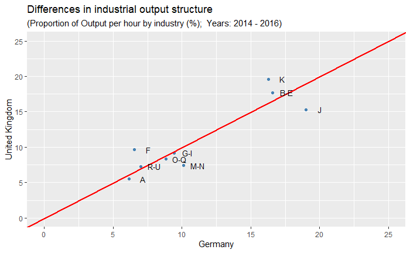

```r
productivity_phw %>%
  select(`A*10 (excl L)`, `NACE Industry`,  `Germany`, `United Kingdom`) %>%
  mutate(
    Germany = 100*Germany/sum(Germany),
    `United Kingdom` = 100*`United Kingdom`/sum(`United Kingdom`),
  ) %>%
  ggplot() +
  aes(
    x = Germany,
    y = `United Kingdom`
    ) +
  geom_point(color = "steelblue") +
  geom_abline(intercept = 0, slope = 1, size = 1, color = "red") +
  geom_text(
    aes(label = `A*10 (excl L)`),
    nudge_x = 1.0,
    nudge_y = 0,
    size = 3.5
  ) +
  ggtitle(
    "Differences in industrial output structure",
    subtitle =  "(Proportion of Output per hour by industry (%);  Years: 2014 - 2016)"
  ) +
  xlim(0, 25) +
  ylim(0, 25)
```

```r
tidy_productivity_phw %>%
  distinct(`A*10 (excl L)`, `NACE Industry`)
```

| A*10 (excl L) | NACE Industry |
| --- | --- |
| A | Agriculture, forestry and fishing |
| B-E | Industry (except construction) |
| F | Construction |
| G-I | Wholesale and retail trade, transport, accommodation and food service activities |
| J | Information and communication |
| K | Financial and insurance activities |
| M-N | Professional, scientific and technical activities; administrative and support service activities |
| O-Q | Public administration, defence, education, human health and social work activities |
| R-U | Arts, entertainment and recreation; other service activities |

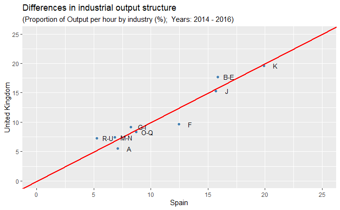

```r
productivity_phw %>%
  select(`A*10 (excl L)`, `NACE Industry`,  `Spain`, `United Kingdom`) %>%
  mutate(
    Spain = 100*Spain/sum(Spain),
    `United Kingdom` = 100*`United Kingdom`/sum(`United Kingdom`),
  ) %>%
  ggplot() +
  aes(
    x = Spain,
    y = `United Kingdom`
    ) +
  geom_point(color = "steelblue") +
  geom_abline(intercept = 0, slope = 1, size = 1, color = "red") +
  geom_text(
    aes(label = `A*10 (excl L)`),
    nudge_x = 1.0,
    nudge_y = 0,
    size = 3.5
  ) +
  ggtitle(
    "Differences in industrial output structure",
    subtitle =  "(Proportion of Output per hour by industry (%);  Years: 2014 - 2016)"
  ) +
  xlim(0, 25) +
  ylim(0, 25)
```

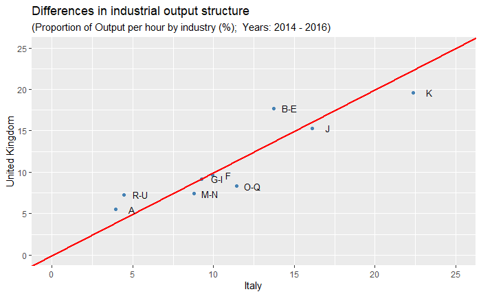

```r
productivity_phw %>%
  select(`A*10 (excl L)`, `NACE Industry`,  `Italy`, `United Kingdom`) %>%
  mutate(
    Italy = 100*Italy/sum(Italy),
    `United Kingdom` = 100*`United Kingdom`/sum(`United Kingdom`),
  ) %>%
  ggplot() +
  aes(
    x = Italy,
    y = `United Kingdom`
    ) +
  geom_point(color = "steelblue") +
  geom_abline(intercept = 0, slope = 1, size = 1, color = "red") +
  geom_text(
    aes(label = `A*10 (excl L)`),
    nudge_x = 1.0,
    nudge_y = 0,
    size = 3.5
  ) +
  ggtitle(
    "Differences in industrial output structure",
    subtitle =  "(Proportion of Output per hour by industry (%);  Years: 2014 - 2016)"
  ) +
  xlim(0, 25) +
  ylim(0, 25)
```

```r
tidy_productivity_phw %>%
  distinct(`A*10 (excl L)`, `NACE Industry`)
```

| A*10 (excl L) | NACE Industry |
| --- | --- |
| A | Agriculture, forestry and fishing |
| B-E | Industry (except construction) |
| F | Construction |
| G-I | Wholesale and retail trade, transport, accommodation and food service activities |
| J | Information and communication |
| K | Financial and insurance activities |
| M-N | Professional, scientific and technical activities; administrative and support service activities |
| O-Q | Public administration, defence, education, human health and social work activities |
| R-U | Arts, entertainment and recreation; other service activities |

Comparison with most productive countries in Europe for 2017: Ireland, Norway Output per hour by industry 2014-16

```r
productivity_phw %>%
  select(`United Kingdom`, Ireland, Norway) %>%
  summarise(
    sum_UK = sum(`United Kingdom`),
    sum_Ireland = sum(Ireland),
    sum_Norway = sum(Norway)
  )
```

| sum_UK | sum_Ireland | sum_Norway |
| --- | --- | --- |
| 246.4642 | 371.6289 | 470.0816 |

```r
NA
```

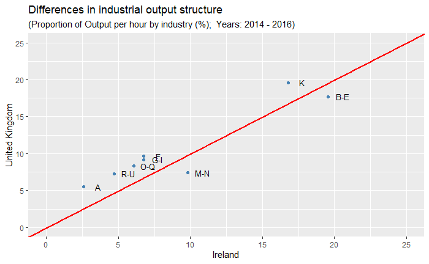

```r
productivity_phw %>%
  select(`A*10 (excl L)`, `NACE Industry`,  `Ireland`, `United Kingdom`) %>%
  mutate(
    Ireland = 100*Ireland/sum(Ireland),
    `United Kingdom` = 100*`United Kingdom`/sum(`United Kingdom`),
  ) %>%
  ggplot() +
  aes(
    x = Ireland,
    y = `United Kingdom`
    ) +
  geom_point(color = "steelblue") +
  geom_abline(intercept = 0, slope = 1, size = 1, color = "red") +
  geom_text(
    aes(label = `A*10 (excl L)`),
    nudge_x = 1.0,
    nudge_y = 0,
    size = 3.5
  ) +
  ggtitle(
    "Differences in industrial output structure",
    subtitle =  "(Proportion of Output per hour by industry (%);  Years: 2014 - 2016)"
  ) +
  xlim(0, 25) +
  ylim(0, 25)
```

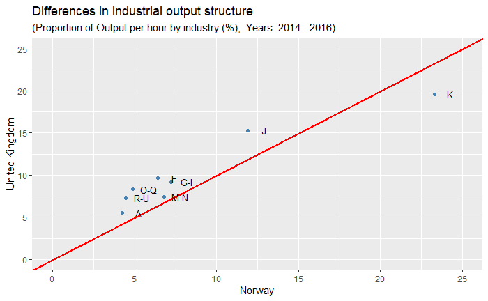

```r
productivity_phw %>%
  select(`A*10 (excl L)`, `NACE Industry`,  `Norway`, `United Kingdom`) %>%
  mutate(
    Norway = 100*Norway/sum(Norway),
    `United Kingdom` = 100*`United Kingdom`/sum(`United Kingdom`),
  ) %>%
  ggplot() +
  aes(
    x = Norway,
    y = `United Kingdom`
    ) +
  geom_point(color = "steelblue") +
  geom_abline(intercept = 0, slope = 1, size = 1, color = "red") +
  geom_text(
    aes(label = `A*10 (excl L)`),
    nudge_x = 1.0,
    nudge_y = 0,
    size = 3.5
  ) +
  ggtitle(
    "Differences in industrial output structure",
    subtitle =  "(Proportion of Output per hour by industry (%);  Years: 2014 - 2016)"
  ) +
  xlim(0, 25) +
  ylim(0, 25)
```

**Compare investment between UK and other countries**

Cross country infrastructure investment

Read data

```r
infrastructure_investment <- read_excel(here("raw_data/Cross_country_infrastructure_investment.xls"))

glimpse(infrastructure_investment)
```

```
Rows: 4,050
Columns: 8
$ LOCATION     <chr> "AUS", "AUS", "AUS", "AUS", "AUS", "AUS", "AUS", "AUS", "AUS", "AUS", "AUS", "AUS", "AUS", "AUS", "AUS", "AUS", "AUS", "AUS", "AUS", "~
$ INDICATOR    <chr> "INFRAINVEST", "INFRAINVEST", "INFRAINVEST", "INFRAINVEST", "INFRAINVEST", "INFRAINVEST", "INFRAINVEST", "INFRAINVEST", "INFRAINVEST",~
$ SUBJECT      <chr> "RAIL", "RAIL", "RAIL", "RAIL", "RAIL", "RAIL", "RAIL", "RAIL", "RAIL", "RAIL", "RAIL", "RAIL", "RAIL", "RAIL", "RAIL", "RAIL", "RAIL"~
$ MEASURE      <chr> "EUR", "EUR", "EUR", "EUR", "EUR", "EUR", "EUR", "EUR", "EUR", "EUR", "EUR", "EUR", "EUR", "EUR", "EUR", "EUR", "EUR", "EUR", "EUR", "~
$ FREQUENCY    <chr> "A", "A", "A", "A", "A", "A", "A", "A", "A", "A", "A", "A", "A", "A", "A", "A", "A", "A", "A", "A", "A", "A", "A", "A", "A", "A", "A",~
$ TIME         <dbl> 1995, 1996, 1997, 1998, 1999, 2000, 2001, 2002, 2003, 2004, 2005, 2006, 2007, 2008, 2009, 2010, 2011, 2012, 2013, 2014, 2015, 2016, 19~
$ Value        <dbl> 5.716267e+08, 8.020111e+08, 7.478865e+08, 6.484921e+08, 5.649573e+08, 4.111802e+08, 3.669105e+08, 6.629548e+08, 7.485239e+08, 1.105364~
$ `Flag Codes` <chr> NA, NA, NA, NA, NA, NA, NA, NA, NA, NA, NA, NA, NA, NA, NA, NA, NA, NA, NA, NA, NA, NA, NA, NA, NA, NA, NA, NA, NA, NA, NA, NA, NA, NA~
```

Change TIME in datetime format

```r
infrastructure_investment <- infrastructure_investment %>%
  mutate(TIME = make_datetime(TIME))
```

```r
infrastructure_investment %>%
  # distinct(LOCATION)
  # distinct(INDICATOR) # INFRAINVEST
  distinct(SUBJECT) #
```

| SUBJECT |
| --- |
| RAIL |
| ROAD |
| INLAND |
| SEA |
| AIR |
| INLANDWATER |

```r
  # distinct(MEASURE) # EUR, PC_GDP
  # distinct(FREQUENCY) #A
  # distinct(`Flag Codes`) # NA, B, P, E, M
```

```r
infrastructure_investment %>%
  summarise(across(.cols = everything(),
                   .fns = ~sum(is.na(.x))))
```

| LOCATION | INDICATOR | SUBJECT | MEASURE | FREQUENCY | TIME | Value | Flag Codes |
| --- | --- | --- | --- | --- | --- | --- | --- |
| 0 | 0 | 0 | 0 | 0 | 0 | 524 | 3423 |

```r
infrastructure_investment %>%
  filter(is.na(Value))
```

| LOCATION | INDICATOR | SUBJECT | MEASURE | FREQUENCY | TIME | Value | Flag Codes |
| --- | --- | --- | --- | --- | --- | --- | --- |
| ISL | INFRAINVEST | RAIL | EUR | A | 1995-01-01 | NA | M |
| ISL | INFRAINVEST | RAIL | EUR | A | 1996-01-01 | NA | M |
| ISL | INFRAINVEST | RAIL | EUR | A | 1997-01-01 | NA | M |
| ISL | INFRAINVEST | RAIL | EUR | A | 1998-01-01 | NA | M |
| ISL | INFRAINVEST | RAIL | EUR | A | 1999-01-01 | NA | M |
| ISL | INFRAINVEST | RAIL | EUR | A | 2000-01-01 | NA | M |
| ISL | INFRAINVEST | RAIL | EUR | A | 2001-01-01 | NA | M |
| ISL | INFRAINVEST | RAIL | EUR | A | 2002-01-01 | NA | M |
| ISL | INFRAINVEST | RAIL | EUR | A | 2003-01-01 | NA | M |
| ISL | INFRAINVEST | RAIL | EUR | A | 2004-01-01 | NA | M |

[output cut: 514 more lines]

G-7 Cross country infrastructure investment (Euros)

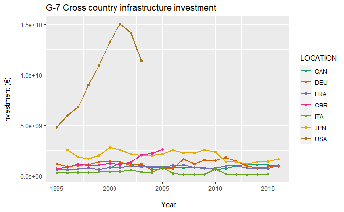

```r
infrastructure_investment %>%
  select(-c(`Flag Codes`, INDICATOR, FREQUENCY)) %>%
  filter(
    LOCATION %in% c("CAN", "FRA", "DEU", "ITA", "JPN", "USA", "GBR"),
    # SUBJECT == "RAIL",
    # SUBJECT == "ROAD",
    # SUBJECT == "SEA",
    SUBJECT == "AIR",
    # SUBJECT == "ROAD",
    MEASURE == "EUR") %>%
  ggplot() +
  aes(x = TIME, y = Value, colour = LOCATION) +
  geom_line(size = 0.75) +
  geom_point(size = 1.5) +
  scale_colour_brewer(palette = "Dark2") +
  ggtitle("G-7 Cross country infrastructure investment") +
  labs(
    x = "\n Year",
    y = "Investment (€) \n"
  )
```

G-7 Cross country infrastructure investment (% of GDP)

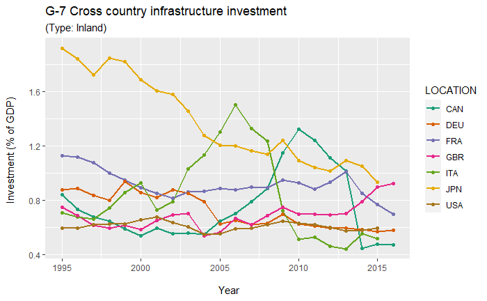

```r
infrastructure_investment %>%
  select(-c(`Flag Codes`, INDICATOR, FREQUENCY)) %>%
  filter(
    LOCATION %in% c("CAN", "FRA", "DEU", "ITA", "JPN", "USA", "GBR"),
    SUBJECT == "INLAND",
    MEASURE == "PC_GDP") %>%
  ggplot() +
  aes(x = TIME, y = Value, colour = LOCATION) +
  geom_line(size = 0.75) +
  geom_point(size = 1.5) +
  scale_colour_brewer(palette = "Dark2") +
  ggtitle(
    "G-7 Cross country infrastructure investment",
    subtitle = "(Type: Inland)"
  ) +
  labs(
    x = "\n Year",
    y = "Investment (% of GDP) \n"
  )
```

[output not shown]

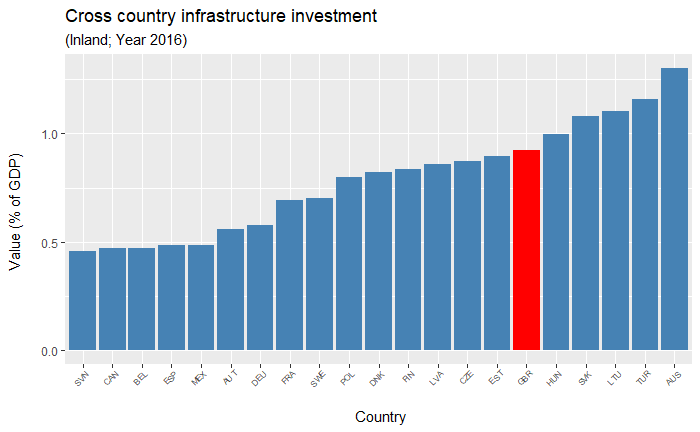

```r
infrastructure_investment %>%
  mutate(TIME = year(TIME)) %>%
  filter(
    # LOCATION %in% c("G-7", "EU28", "CAN", "FRA", "DEU", "ITA", "JPN", "USA", "GBR"),
    SUBJECT == "INLAND",
    MEASURE == "PC_GDP", # "EUR",
    TIME == 2016
    ) %>%
  select(-c(`Flag Codes`, INDICATOR, FREQUENCY, SUBJECT, MEASURE, TIME)) %>%
  ggplot() +
  aes(
    x = reorder(LOCATION, Value),
    y = Value,
    fill = reorder(LOCATION, Value) == "GBR"
    ) +
  geom_col() +
  scale_fill_manual(values = c('steelblue', 'red'), guide = "none") +
  theme(
    axis.text.x = element_text(size = 6, angle = 45, vjust = 1.15, hjust = 1)
  ) +
  ggtitle(
    "Cross country infrastructure investment",
    subtitle =  "(Inland; Year 2016)"
  ) +
  labs(
    x = "\n Country",
    y = "Value (% of GDP) \n"
  )
```

Comparison with large economies in Europe: UK, France, Germany, Italy, Spain (the Netherlands)

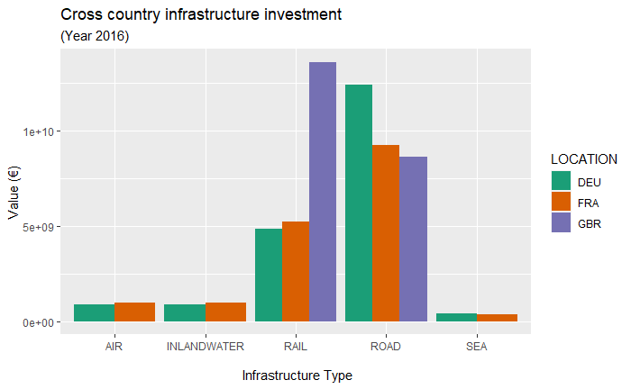

```r
infrastructure_investment %>%
  mutate(TIME = year(TIME)) %>%
  filter(
    LOCATION %in% c("GBR", "FRA", "DEU"),
    MEASURE == "EUR", #"PC_GDP", #
    TIME == 2016
  ) %>%
  ggplot() +
  aes(
    x = SUBJECT,
    y = Value,
    fill = LOCATION
    ) +
  geom_col(position = "dodge") +
  scale_fill_brewer(palette = "Dark2") +
  ggtitle(
    "Cross country infrastructure investment",
    subtitle =  "(Year 2016)"
  ) +
  labs(
    x = "\n Infrastructure Type",
    y = "Value (€)"
  )
```

Comparison with most productive countries in Europe (2017): UK, Ireland, Norway

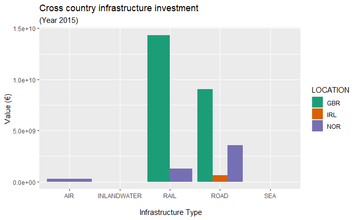

```r
infrastructure_investment %>%
  mutate(TIME = year(TIME)) %>%
  filter(
    LOCATION %in% c("GBR", "IRL", "NOR"),
    MEASURE == "EUR", #"PC_GDP", #
    TIME == 2015
  ) %>%
  ggplot() +
  aes(
    x = SUBJECT,
    y = Value,
    fill = LOCATION
    ) +
  geom_col(position = "dodge") +
  scale_fill_brewer(palette = "Dark2") +
  ggtitle(
    "Cross country infrastructure investment",
    subtitle =  "(Year 2015)"
  ) +
  labs(
    x = "\n Infrastructure Type",
    y = "Value (€)"
  )
```

Cross Country Gross Domestic Spending on R&D

Read data

```r
gdexp_rd <- read_excel(here("raw_data/Cross_country_Gross_Domestic_Spending_on_R&D.xls"))

glimpse(gdexp_rd)
```

```
Rows: 1,960
Columns: 8
$ LOCATION     <chr> "AUS", "AUS", "AUS", "AUS", "AUS", "AUS", "AUS", "AUS", "AUS", "AUS", "AUS", "AUS", "AUS", "AUS", "AUS", "AUS", "AUS", "AUS", "AUS", "~
$ INDICATOR    <chr> "GDEXPRD", "GDEXPRD", "GDEXPRD", "GDEXPRD", "GDEXPRD", "GDEXPRD", "GDEXPRD", "GDEXPRD", "GDEXPRD", "GDEXPRD", "GDEXPRD", "GDEXPRD", "G~
$ SUBJECT      <chr> "TOT", "TOT", "TOT", "TOT", "TOT", "TOT", "TOT", "TOT", "TOT", "TOT", "TOT", "TOT", "TOT", "TOT", "TOT", "TOT", "TOT", "TOT", "TOT", "~
$ MEASURE      <chr> "MLN_USD", "MLN_USD", "MLN_USD", "MLN_USD", "MLN_USD", "MLN_USD", "MLN_USD", "MLN_USD", "MLN_USD", "MLN_USD", "MLN_USD", "MLN_USD", "M~
$ FREQUENCY    <chr> "A", "A", "A", "A", "A", "A", "A", "A", "A", "A", "A", "A", "A", "A", "A", "A", "A", "A", "A", "A", "A", "A", "A", "A", "A", "A", "A",~
$ TIME         <dbl> 1981, 1984, 1986, 1987, 1988, 1990, 1992, 1994, 1996, 1998, 2000, 2002, 2004, 2006, 2008, 2010, 2011, 2013, 2015, 1981, 1984, 1986, 19~
$ Value        <dbl> 3.405069e+03, 4.157530e+03, 5.106088e+03, 5.205378e+03, 5.529401e+03, 6.176635e+03, 7.492037e+03, 8.351390e+03, 9.459464e+03, 9.440657~
$ `Flag Codes` <lgl> NA, NA, NA, NA, NA, NA, NA, NA, NA, NA, NA, NA, NA, NA, NA, NA, NA, NA, NA, NA, NA, NA, NA, NA, NA, NA, NA, NA, NA, NA, NA, NA, NA, NA~
```

Change TIME in datetime format

```r
gdexp_rd <- gdexp_rd %>%
  mutate(TIME = make_datetime(TIME))
```

```r
gdexp_rd %>%
  distinct(LOCATION)
```

| LOCATION |
| --- |
| AUS |
| AUT |
| BEL |
| CAN |
| CZE |
| DNK |
| FIN |
| FRA |
| DEU |
| GRC |

[output cut: 25 more lines]

```r
  # distinct(INDICATOR) # GDEXPRD
  # distinct(SUBJECT) # TOT
  # distinct(MEASURE) # MLN_USD, PC_GDP
  # distinct(FREQUENCY) #A
  # distinct(`Flag Codes`) # NA
```

Check for NA’s

```r
gdexp_rd %>%
  summarise(across(.cols = everything(),
                   .fns = ~sum(is.na(.x))))
```

| LOCATION | INDICATOR | SUBJECT | MEASURE | FREQUENCY | TIME | Value | Flag Codes |
| --- | --- | --- | --- | --- | --- | --- | --- |
| 0 | 0 | 0 | 0 | 0 | 0 | 0 | 1960 |

G-7 countries gross domestic expenditure on R&D (Million USD)

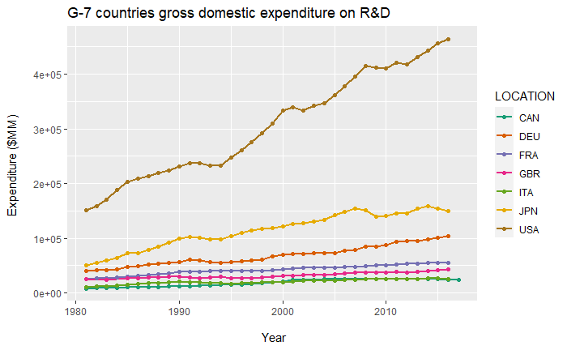

```r
gdexp_rd %>%
  select(-c(`Flag Codes`, INDICATOR, FREQUENCY, SUBJECT)) %>%
  filter(LOCATION %in% c("CAN", "FRA", "DEU", "ITA", "JPN", "USA", "GBR"),
         MEASURE == "MLN_USD") %>%
  ggplot() +
  aes(x = TIME, y = Value, colour = LOCATION) +
  geom_line(size = 0.75) +
  geom_point(size = 1.5) +
  scale_colour_brewer(palette = "Dark2") +
  ggtitle("G-7 countries gross domestic expenditure on R&D") +
  labs(
    x = "\n Year",
    y = "Expenditure ($MM) \n"
  )
```

KEEP THIS FIGURE!!!!

G-7 countries gross domestic expenditure on R&D (% GDP)

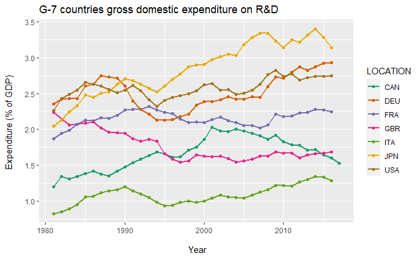

```r
gdexp_rd %>%
  select(-c(`Flag Codes`, INDICATOR, FREQUENCY, SUBJECT)) %>%
  filter(
    LOCATION %in% c("CAN", "FRA", "DEU", "ITA", "JPN", "USA", "GBR"),
    # LOCATION %in% c( "FRA", "DEU", "USA", "GBR"),
    MEASURE == "PC_GDP"
    ) %>%
  ggplot() +
  aes(x = TIME, y = Value, colour = LOCATION) +
  geom_line(size = 0.75) +
  geom_point(size = 1.5) +
  scale_colour_brewer(palette = "Dark2") +
  ggtitle("G-7 countries gross domestic expenditure on R&D") +
  labs(
    x = "\n Year",
    y = "Expenditure (% of GDP) \n"
  )
```

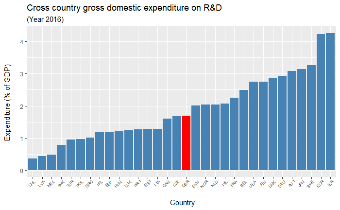

```r
gdexp_rd %>%
  mutate(TIME = year(TIME)) %>%
  filter(
    # LOCATION %in% c("G-7", "EU28", "CAN", "FRA", "DEU", "ITA", "JPN", "USA", "GBR"),
    MEASURE == "PC_GDP",
    TIME == 2016
    ) %>%
  select(-c(`Flag Codes`, INDICATOR, FREQUENCY, SUBJECT, MEASURE, TIME)) %>%
  ggplot() +
  aes(
    x = reorder(LOCATION, Value),
    y = Value,
    fill = reorder(LOCATION, Value) == "GBR"
    ) +
  geom_col() +
  scale_fill_manual(values = c('steelblue', 'red'), guide = "none") +
  theme(
    axis.text.x = element_text(size = 6, angle = 45, vjust = 1.15, hjust = 1)
  ) +
  ggtitle(
    "Cross country gross domestic expenditure on R&D",
    subtitle =  "(Year 2016)"
  ) +
  labs(
    x = "\n Country",
    y = "Expenditure (% of GDP) \n"
  )
```

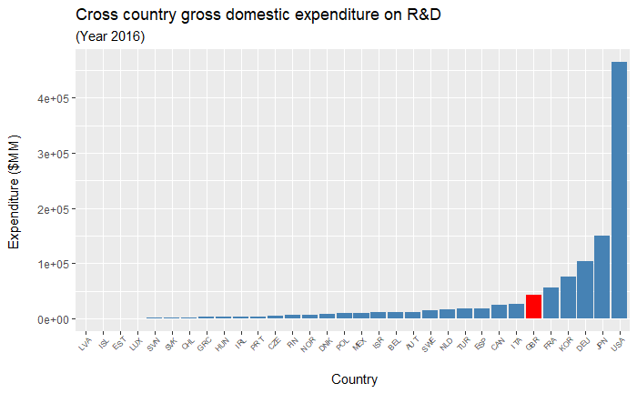

```r
gdexp_rd %>%
  mutate(TIME = year(TIME)) %>%
  filter(
    # LOCATION %in% c("G-7", "EU28", "CAN", "FRA", "DEU", "ITA", "JPN", "USA", "GBR"),
    MEASURE == "MLN_USD",
    TIME == 2016
    ) %>%
  select(-c(`Flag Codes`, INDICATOR, FREQUENCY, SUBJECT, MEASURE, TIME)) %>%
  ggplot() +
  aes(
    x = reorder(LOCATION, Value),
    y = Value,
    fill = reorder(LOCATION, Value) == "GBR"
    ) +
  geom_col() +
  scale_fill_manual(values = c('steelblue', 'red'), guide = "none") +
  theme(
    axis.text.x = element_text(size = 6, angle = 45, vjust = 1.15, hjust = 1)
  ) +
  ggtitle(
    "Cross country gross domestic expenditure on R&D",
    subtitle =  "(Year 2016)"
  ) +
  labs(
    x = "\n Country",
    y = "Expenditure ($MM) \n"
  )
```

**Comparison of Private Sector In Economy**

Read data

```r
private_sector <- read_excel(here("raw_data/Private_Sector_In_Economy.xlsx"), sheet = "5.1_Private_sector R-proc")

glimpse(private_sector)
```

```
Rows: 226
Columns: 13
$ Country                                    <chr> "Afghanistan", "Albania", "Algeria", "American Samoa", "Andorra", "Angola", "Antigua and Barbuda", "Arge~
$ `Energy $ millions 2006-11`                <chr> "..", "711.6", "2670", "..", "..", "129.4", "..", "4366.5", "512.1", "..", "..", "..", "..", "..", "..",~
$ `Energy $ millions 2012-17`                <chr> "..", "351.8", "30.3", "..", "..", "..", "..", "1985.6", "250", "..", "..", "..", "..", "..", "..", "287~
$ `Transport $ millions 2006-11`             <chr> "..", "..", "269", "..", "..", "53", "..", "1637.1", "715", "..", "..", "..", "..", "..", "..", "..", ".~
$ `Transport $ millions 2012-17`             <chr> "..", "51.3", "..", "..", "..", "..", "..", "250.5", "101", "..", "..", "..", "..", "..", "..", "..", ".~
$ `Water and sanitation $ millions 2006-11`  <chr> "..", "..", "1572", "..", "..", "..", "..", "..", "..", "..", "..", "..", "..", "..", "..", "..", "..", ~
$ `Water and sanitation $ millions 2012-17`  <chr> "..", "..", "..", "..", "..", "..", "..", "..", "200", "..", "..", "..", "..", "..", "..", "..", "..", "~
$ `ICT $ 2006-11`                            <chr> "..", "..", "..", "..", "..", "..", "..", "..", "..", "..", "..", "..", "..", "..", "..", "..", "..", ".~
$ `ICT $ 2012-17`                            <chr> "..", "..", "162000000", "..", "..", "..", "..", "1619000000", "..", "..", "..", "..", "..", "..", "..",~
$ `Domestic credit % of GDP 2006-11`         <chr> "47.8", "206", "83.1", "..", "..", "93.3", "425.1", "76.400000000000006", "130.5", "332.3", "728.2", "57~
$ `Domestic credit % of GDP 2012-17`         <chr> "25", "234.7", "107.3", "..", "..", "137.30000000000001", "373.7", "86.9", "261.2", "57.4", "776.9", "54~
$ `Businesses registered New 2016`           <chr> "3492", "2679", "15574", "..", "..", "..", "279", "11672", "3573", "..", "246623", "3486", "7218", "..",~
$ `Businesses registered Entry density 2016` <chr> "0.19", "1.35", "0.57999999999999996", "..", "..", "..", "4.01", "0.43", "1.74", "..", "15.51", "0.6", "~
```

Check for NA’s

```r
private_sector %>%
  summarise(across(.cols = everything(),
                   .fns = ~sum(is.na(.x))))
```

| Country | Energy $ millions 2006-11 | Energy $ millions 2012-17 | Transport $ millions 2006-11 | Transport $ millions 2012-17 | Water and sanitation $ millions 2006-11 | Water and sanitation $ millions 2012-17 | ICT $ 2006-11 | ICT $ 2012-17 | Domestic credit % of GDP 2006-11 | Domestic credit % of GDP 2012-17 | Businesses registered New 2016 | Businesses registered Entry density 2016 |
| --- | --- | --- | --- | --- | --- | --- | --- | --- | --- | --- | --- | --- |
| 0 | 0 | 0 | 0 | 0 | 0 | 0 | 0 | 0 | 0 | 0 | 0 | 0 |

Remove junk and change data type to numeric in all columns except `Country` and turn ICT variables to millions of USD

```r
private_sector_clean <- private_sector %>%
  select(-c(`Businesses registered New 2016`, `Businesses registered Entry density 2016`)) %>%
  mutate(
    across(
      .cols = where(is.character) & !Country,
      .fns = ~as.numeric(.x)
    )
  ) %>%
  mutate(
    `ICT $ 2006-11` = `ICT $ 2006-11`/1000000,
    `ICT $ 2012-17` = `ICT $ 2012-17`/1000000
  )
glimpse(private_sector_clean)
```

```
Rows: 226
Columns: 11
$ Country                                   <chr> "Afghanistan", "Albania", "Algeria", "American Samoa", "Andorra", "Angola", "Antigua and Barbuda", "Argen~
$ `Energy $ millions 2006-11`               <dbl> NA, 711.6, 2670.0, NA, NA, 129.4, NA, 4366.5, 512.1, NA, NA, NA, NA, NA, NA, 793.5, NA, 5000.0, NA, 220.2~
$ `Energy $ millions 2012-17`               <dbl> NA, 351.8, 30.3, NA, NA, NA, NA, 1985.6, 250.0, NA, NA, NA, NA, NA, NA, 2879.1, NA, 2500.0, NA, NA, NA, N~
$ `Transport $ millions 2006-11`            <dbl> NA, NA, 269.0, NA, NA, 53.0, NA, 1637.1, 715.0, NA, NA, NA, NA, NA, NA, NA, NA, 4.0, NA, NA, 489.0, NA, N~
$ `Transport $ millions 2012-17`            <dbl> NA, 51.3, NA, NA, NA, NA, NA, 250.5, 101.0, NA, NA, NA, NA, NA, NA, NA, NA, NA, NA, NA, NA, NA, NA, NA, N~
$ `Water and sanitation $ millions 2006-11` <dbl> NA, NA, 1572.0, NA, NA, NA, NA, NA, NA, NA, NA, NA, NA, NA, NA, NA, NA, NA, NA, NA, NA, NA, NA, NA, NA, N~
$ `Water and sanitation $ millions 2012-17` <dbl> NA, NA, NA, NA, NA, NA, NA, NA, 200.0, NA, NA, NA, NA, NA, NA, NA, NA, NA, NA, NA, NA, NA, NA, NA, NA, NA~
$ `ICT $ 2006-11`                           <dbl> NA, NA, NA, NA, NA, NA, NA, NA, NA, NA, NA, NA, NA, NA, NA, NA, NA, NA, NA, NA, NA, NA, NA, NA, NA, NA, N~
$ `ICT $ 2012-17`                           <dbl> NA, NA, 162, NA, NA, NA, NA, 1619, NA, NA, NA, NA, NA, NA, NA, NA, NA, NA, NA, NA, NA, NA, NA, NA, NA, NA~
$ `Domestic credit % of GDP 2006-11`        <dbl> 47.8, 206.0, 83.1, NA, NA, 93.3, 425.1, 76.4, 130.5, 332.3, 728.2, 575.5, 96.0, 374.5, 370.9, 216.9, 309.~
$ `Domestic credit % of GDP 2012-17`        <dbl> 25.0, 234.7, 107.3, NA, NA, 137.3, 373.7, 86.9, 261.2, 57.4, 776.9, 540.4, 158.0, 353.7, 345.9, 260.7, NA~
```

Pivot data to long format

```r
private_sector_investment <- private_sector_clean %>%
  select(-c(`Domestic credit % of GDP 2006-11`, `Domestic credit % of GDP 2012-17`)) %>%
  pivot_longer(
    cols = -Country,
    names_to = "sector",
    values_to = "mln_usd"
  ) %>%
  mutate(
    period = str_sub(sector, -7),
    sector = str_remove(sector, pattern = " \\$.*")
  ) %>%
  relocate(period, .after = sector) %>%
  clean_names()

private_sector_investment
```

| country | sector | period | mln_usd |
| --- | --- | --- | --- |
| Afghanistan | Energy | 2006-11 | NA |
| Afghanistan | Energy | 2012-17 | NA |
| Afghanistan | Transport | 2006-11 | NA |
| Afghanistan | Transport | 2012-17 | NA |
| Afghanistan | Water and sanitation | 2006-11 | NA |
| Afghanistan | Water and sanitation | 2012-17 | NA |
| Afghanistan | ICT | 2006-11 | NA |
| Afghanistan | ICT | 2012-17 | NA |
| Albania | Energy | 2006-11 | 711.6 |
| Albania | Energy | 2012-17 | 351.8 |

[output cut: 990 more lines]

```r
domestic_credit_to_private_sector <- private_sector_clean %>%
  select(`Country`, `Domestic credit % of GDP 2006-11`, `Domestic credit % of GDP 2012-17`) %>%
  pivot_longer(
    cols = -Country,
    names_to = "period",
    values_to = "gdp_pc"
  ) %>%
  mutate(
    period = str_sub(period, -7)
  ) %>%
  clean_names()

domestic_credit_to_private_sector
```

| country | period | gdp_pc |
| --- | --- | --- |
| Afghanistan | 2006-11 | 47.8 |
| Afghanistan | 2012-17 | 25.0 |
| Albania | 2006-11 | 206.0 |
| Albania | 2012-17 | 234.7 |
| Algeria | 2006-11 | 83.1 |
| Algeria | 2012-17 | 107.3 |
| American Samoa | 2006-11 | NA |
| American Samoa | 2012-17 | NA |
| Andorra | 2006-11 | NA |
| Andorra | 2012-17 | NA |

[output cut: 442 more lines]

```r
private_sector_investment %>%
  distinct(country)
```

| country |
| --- |
| Afghanistan |
| Albania |
| Algeria |
| American Samoa |
| Andorra |
| Angola |
| Antigua and Barbuda |
| Argentina |
| Armenia |
| Aruba |

[output cut: 216 more lines]

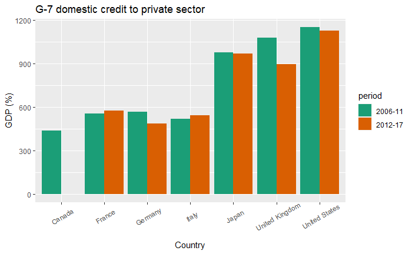

```r
domestic_credit_to_private_sector %>%
  filter(
    country %in% c("Canada", "France", "Germany", "Italy", "Japan", "United States", "United Kingdom")
  ) %>%
  ggplot() +
  aes(x = country, y = gdp_pc, fill  = period) +
  geom_col(position = "dodge") +
  scale_fill_brewer(palette = "Dark2") +
  theme(
    axis.text.x = element_text(angle = 30, vjust = 0.75)
  ) +
  ggtitle("G-7 domestic credit to private sector") +
  labs(
    x = "Country",
    y = "GDP (%)"
  )
```

**Compare skills and education between UK and other countries**

OECD Adult Education Levels

Read data

```r
adult_education <- read_excel(here("raw_data/OECD_Adult_Education_Levels.xlsx"))

glimpse(adult_education)
```

```
Rows: 869
Columns: 8
$ LOCATION     <chr> "AUS", "AUS", "AUS", "AUS", "AUS", "AUS", "AUS", "AUS", "AUS", "AUS", "AUS", "AUS", "AUS", "AUS", "AUS", "AUS", "AUS", "AUS", "AUS", "~
$ INDICATOR    <chr> "EDUADULT", "EDUADULT", "EDUADULT", "EDUADULT", "EDUADULT", "EDUADULT", "EDUADULT", "EDUADULT", "EDUADULT", "EDUADULT", "EDUADULT", "E~
$ SUBJECT      <chr> "TRY", "TRY", "TRY", "TRY", "TRY", "TRY", "TRY", "TRY", "TRY", "TRY", "TRY", "TRY", "TRY", "TRY", "TRY", "TRY", "TRY", "TRY", "TRY", "~
$ MEASURE      <chr> "PC_25_64", "PC_25_64", "PC_25_64", "PC_25_64", "PC_25_64", "PC_25_64", "PC_25_64", "PC_25_64", "PC_25_64", "PC_25_64", "PC_25_64", "P~
$ FREQUENCY    <chr> "A", "A", "A", "A", "A", "A", "A", "A", "A", "A", "A", "A", "A", "A", "A", "A", "A", "A", "A", "A", "A", "A", "A", "A", "A", "A", "A",~
$ TIME         <dbl> 1989, 1991, 1993, 1994, 1995, 1997, 1998, 1999, 2000, 2001, 2002, 2003, 2004, 2005, 2006, 2007, 2008, 2009, 2010, 2011, 2012, 2013, 20~
$ Value        <dbl> 30.58148, 31.15881, 22.46919, 23.07237, 24.31545, 24.30127, 25.42071, 26.69340, 27.47575, 28.97732, 30.75979, 31.31415, 30.82308, 31.6~
$ `Flag Codes` <lgl> NA, NA, NA, NA, NA, NA, NA, NA, NA, NA, NA, NA, NA, NA, NA, NA, NA, NA, NA, NA, NA, NA, NA, NA, NA, NA, NA, NA, NA, NA, NA, NA, NA, NA~
```

Change TIME in datetime format

```r
adult_education <- adult_education %>%
  mutate(TIME = make_datetime(TIME))
```

Check for NA’s

```r
adult_education %>%
  summarise(across(.cols = everything(),
                   .fns = ~sum(is.na(.x))))
```

| LOCATION | INDICATOR | SUBJECT | MEASURE | FREQUENCY | TIME | Value | Flag Codes |
| --- | --- | --- | --- | --- | --- | --- | --- |
| 0 | 0 | 0 | 0 | 0 | 0 | 0 | 869 |

```r
adult_education %>%
  distinct(LOCATION)
```

| LOCATION |
| --- |
| AUS |
| AUT |
| BEL |
| CAN |
| CZE |
| DNK |
| FIN |
| FRA |
| DEU |
| GRC |

[output cut: 38 more lines]

```r
  # distinct(INDICATOR) # EDUADULT
  # distinct(SUBJECT) # TRY
  # distinct(MEASURE) # PC_25_64
  # distinct(FREQUENCY) #A
  # distinct(`Flag Codes`) # NA
```

G-7 countries adult education levels 25-64

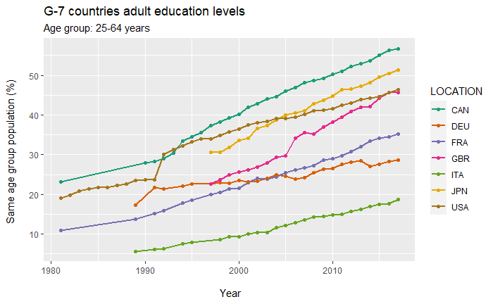

```r
adult_education %>%
  select(-c(`Flag Codes`, INDICATOR, FREQUENCY, SUBJECT, MEASURE)) %>%
  filter(LOCATION %in% c("CAN", "FRA", "DEU", "ITA", "JPN", "USA", "GBR")) %>%
  ggplot() +
  aes(x = TIME, y = Value, colour = LOCATION) +
  geom_line(size = 0.75) +
  geom_point(size = 1.5) +
  scale_colour_brewer(palette = "Dark2") +
  # scale_colour_manual(values = cbb_palette) +
  ggtitle(
    "G-7 countries adult education levels",
    subtitle = "Age group: 25-64 years"
  ) +
  labs(
    x = "\n Year",
    y = "Same age group population (%) \n"
  )
```

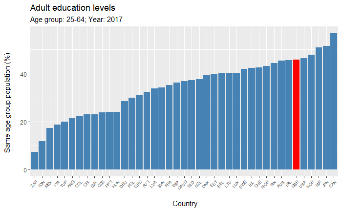

```r
adult_education %>%
 mutate(TIME = year(TIME)) %>%
  filter(
    TIME == 2017
    ) %>%
  select(-c(`Flag Codes`, INDICATOR, FREQUENCY, SUBJECT, MEASURE, TIME)) %>%
  ggplot() +
  aes(
    x = reorder(LOCATION, Value),
    y = Value,
    fill = reorder(LOCATION, Value) == "GBR"
    ) +
  geom_col() +
  scale_fill_manual(values = c('steelblue', 'red'), guide = "none") +
  theme(
    axis.text.x = element_text(size = 6, angle = 45, vjust = 1, hjust = 1)
    ) +
  ggtitle(
    "Adult education levels",
    subtitle = "Age group: 25-64; Year: 2017"
  ) +
  labs(
    x = "\n Country",
    y = "Same age group population (%) \n"
  )
```

OECD Quality of human capital - Better to combine the data sets from the 3 sheets in file below

Read data

```r
overqualified_workers <- read_excel(here("raw_data/OECD_Quality_of_human_capital.xlsx"), sheet = "Prop Workers Overqualified R-pr")
underqualified_workers <- read_excel(here("raw_data/OECD_Quality_of_human_capital.xlsx"), sheet = "Prop Worker Underqualified R-pr")
qualified_workers <- read_excel(here("raw_data/OECD_Quality_of_human_capital.xlsx"), sheet = "Prop Workers Well-matched R-pr")

glimpse(overqualified_workers)
```

```
Rows: 30
Columns: 12
$ Country <chr> "Austria", "Belgium", "Czech Republic", "Denmark", "Estonia", "Finland", "France", "Germany", "Greece", "Hungary", "Iceland", "Ireland", "I~
$ `2003`  <chr> "14.626659999999999", "15.67394", "6.3963359999999998", "11.80269", "15.715339999999999", "6.3768830000000003", "8.6296999999999997", "14.4~
$ `2004`  <chr> "11.427210000000001", "16.09684", "6.667999", "8.6670750000000005", "9.4853129999999997", "6.5261969999999998", "8.8837019999999995", "15.2~
$ `2005`  <chr> "10.128360000000001", "17.403600000000001", "6.8644299999999996", "8.6756919999999997", "16.931249999999999", "6.2529019999999997", "9.5460~
$ `2006`  <chr> "9.7320309999999992", "16.70701", "7.1417780000000004", "8.4196969999999993", "9.4026750000000003", "6.264087", "9.9316870000000002", "13.3~
$ `2007`  <chr> "9.6274180000000005", "13.093450000000001", "7.2991060000000001", "11.088609999999999", "9.4490160000000003", "6.4440289999999996", "10.132~
$ `2008`  <chr> "9.8553270000000008", "12.70077", "8.1115429999999993", "11.653700000000001", "9.7653569999999998", "6.5493300000000003", "10.85169", "14.2~
$ `2009`  <chr> "10.188829999999999", "12.887829999999999", "8.625337", "10.310969999999999", "10.161910000000001", "7.0602200000000002", "11.22864", "14.9~
$ `2010`  <chr> "10.1508", "13.19087", "9.1689249999999998", "10.18207", "9.3881610000000002", "6.7603169999999997", "10.97677", "14.67305", "20.6942200000~
$ `2011`  <dbl> 9.861244, 13.390160, 6.922071, 12.993560, 9.928575, 5.060633, 20.069520, 12.263070, 21.039210, 8.030221, 21.208520, 22.131540, 20.993220, 1~
$ `2012`  <chr> "10.1135", "13.241440000000001", "7.1548210000000001", "13.217739999999999", "10.68723", "4.9735670000000001", "20.572030000000002", "13.47~
$ `2013`  <chr> "10.261189999999999", "13.441560000000001", "7.5550420000000003", "13.295669999999999", "11.17657", "4.8881220000000001", "13.1899700000000~
```

```r
glimpse(underqualified_workers)
```

```
Rows: 30
Columns: 12
$ Country <chr> "Austria", "Belgium", "Czech Republic", "Denmark", "Estonia", "Finland", "France", "Germany", "Greece", "Hungary", "Iceland", "Ireland", "I~
$ `2003`  <chr> "16.589839999999999", "27.295490000000001", "10.182460000000001", "25.67089", "18.241499999999998", "31.323129999999999", "34.7008000000000~
$ `2004`  <chr> "18.22569", "25.178650000000001", "9.9050019999999996", "27.819469999999999", "23.680540000000001", "30.258880000000001", "34.10127", "17.4~
$ `2005`  <chr> "18.094609999999999", "24.63653", "8.7599809999999998", "28.136769999999999", "16.810490000000001", "29.981729999999999", "33.4005799999999~
$ `2006`  <chr> "19.17831", "25.26304", "8.7935979999999994", "27.98798", "23.37256", "29.983809999999998", "32.946280000000002", "18.105989999999998", "10~
$ `2007`  <chr> "20.14564", "27.828939999999999", "9.2263640000000002", "30.111750000000001", "24.277249999999999", "29.14658", "32.155679999999997", "17.6~
$ `2008`  <chr> "19.101040000000001", "27.91197", "9.1729769999999995", "29.835989999999999", "23.840029999999999", "27.811620000000001", "31.3054200000000~
$ `2009`  <chr> "18.018820000000002", "27.286180000000002", "8.4656719999999996", "31.533850000000001", "21.761520000000001", "26.575579999999999", "30.619~
$ `2010`  <chr> "17.612089999999998", "26.875800000000002", "6.1168579999999997", "30.854030000000002", "21.50488", "26.801469999999998", "29.6947000000000~
$ `2011`  <dbl> 20.306070, 24.665540, 9.754188, 22.015430, 21.479270, 26.755500, 21.316550, 19.029380, 13.704310, 14.781820, 16.341900, 18.532320, 16.02483~
$ `2012`  <chr> "19.90757", "24.254200000000001", "9.6735199999999999", "20.91273", "21.66358", "26.28942", "20.472349999999999", "18.032830000000001", "12~
$ `2013`  <chr> "19.919160000000002", "23.271159999999998", "9.6902039999999996", "20.220410000000001", "20.869769999999999", "26.306010000000001", "26.344~
```

```r
glimpse(qualified_workers)
```

```
Rows: 30
Columns: 12
$ Country <chr> "Austria", "Belgium", "Czech Republic", "Denmark", "Estonia", "Finland", "France", "Germany", "Greece", "Hungary", "Iceland", "Ireland", "I~
$ `2003`  <chr> "68.783510000000007", "57.030569999999997", "83.421199999999999", "62.526420000000002", "66.04316", "62.299990000000001", "56.6694999999999~
$ `2004`  <chr> "70.347110000000001", "58.724510000000002", "83.427000000000007", "63.513449999999999", "66.834149999999994", "63.214919999999999", "57.015~
$ `2005`  <chr> "71.77704", "57.959870000000002", "84.375590000000003", "63.187539999999998", "66.258260000000007", "63.765369999999997", "57.0533799999999~
$ `2006`  <chr> "71.089659999999995", "58.029949999999999", "84.064620000000005", "63.592320000000001", "67.224770000000007", "63.752099999999999", "57.122~
$ `2007`  <chr> "70.226939999999999", "59.077599999999997", "83.474530000000001", "58.799639999999997", "66.273740000000004", "64.409390000000002", "57.711~
$ `2008`  <chr> "71.043629999999993", "59.387259999999998", "82.715479999999999", "58.510309999999997", "66.394620000000003", "65.639049999999997", "57.842~
$ `2009`  <chr> "71.792360000000002", "59.825980000000001", "82.908990000000003", "58.155180000000001", "68.076560000000001", "66.364199999999997", "58.151~
$ `2010`  <chr> "72.237110000000001", "59.933329999999998", "84.714219999999997", "58.963909999999998", "69.106960000000001", "66.438209999999998", "59.328~
$ `2011`  <dbl> 69.83269, 61.94429, 83.32374, 64.99100, 68.59216, 68.18387, 58.61393, 68.70755, 65.25648, 77.18797, 62.44958, 59.33614, 62.98195, 71.03859,~
$ `2012`  <chr> "69.978930000000005", "62.504359999999998", "83.171660000000003", "65.869519999999994", "67.649190000000004", "68.737009999999998", "58.955~
$ `2013`  <chr> "69.819640000000007", "63.287280000000003", "82.754750000000001", "66.483919999999998", "67.953670000000002", "68.805869999999999", "60.466~
```

Change data type to numeric in all columns except `Country`

```r
overqualified_workers_clean <- overqualified_workers %>%
  mutate(
    across(
      .cols = where(is.character) & !Country,
      .fns = ~as.numeric(.x)
    )
  )
underqualified_workers_clean <- underqualified_workers %>%
  mutate(
    across(
      .cols = where(is.character) & !Country,
      .fns = ~as.numeric(.x)
    )
  )
qualified_workers_clean <- qualified_workers %>%
  mutate(
    across(
      .cols = where(is.character) & !Country,
      .fns = ~as.numeric(.x)
    )
  )
glimpse(overqualified_workers_clean)
```

```
Rows: 30
Columns: 12
$ Country <chr> "Austria", "Belgium", "Czech Republic", "Denmark", "Estonia", "Finland", "France", "Germany", "Greece", "Hungary", "Iceland", "Ireland", "I~
$ `2003`  <dbl> 14.626660, 15.673940, 6.396336, 11.802690, 15.715340, 6.376883, 8.629700, 14.484100, 23.002600, 10.588420, 21.338870, 19.212060, 22.427750,~
$ `2004`  <dbl> 11.427210, 16.096840, 6.667999, 8.667075, 9.485313, 6.526197, 8.883702, 15.252510, 23.531340, 11.706420, 22.398250, 20.269080, 25.332150, 1~
$ `2005`  <dbl> 10.128360, 17.403600, 6.864430, 8.675692, 16.931250, 6.252902, 9.546042, 14.234110, 23.695570, 12.647710, 22.516620, 20.877630, 22.920960, ~
$ `2006`  <dbl> 9.732031, 16.707010, 7.141778, 8.419697, 9.402675, 6.264087, 9.931687, 13.350170, 22.896310, 12.576580, 19.602300, 22.009390, 23.867390, 13~
$ `2007`  <dbl> 9.627418, 13.093450, 7.299106, 11.088610, 9.449016, 6.444029, 10.132770, 13.922200, 19.352840, 12.799360, 20.453490, 23.297990, 24.564010, ~
$ `2008`  <dbl> 9.855327, 12.700770, 8.111543, 11.653700, 9.765357, 6.549330, 10.851690, 14.208820, 19.901250, 14.383380, 17.998580, 24.139820, 20.161810, ~
$ `2009`  <dbl> 10.188830, 12.887830, 8.625337, 10.310970, 10.161910, 7.060220, 11.228640, 14.982890, 20.135810, 14.871600, 19.363940, 19.506310, 21.183870~
$ `2010`  <dbl> 10.150800, 13.190870, 9.168925, 10.182070, 9.388161, 6.760317, 10.976770, 14.673050, 20.694220, 10.800870, 19.405460, 20.271570, 22.128330,~
$ `2011`  <dbl> 9.861244, 13.390160, 6.922071, 12.993560, 9.928575, 5.060633, 20.069520, 12.263070, 21.039210, 8.030221, 21.208520, 22.131540, 20.993220, 1~
$ `2012`  <dbl> 10.113500, 13.241440, 7.154821, 13.217740, 10.687230, 4.973567, 20.572030, 13.474930, 23.545760, 8.569489, 22.203750, 15.854230, 21.500260,~
$ `2013`  <dbl> 10.261190, 13.441560, 7.555042, 13.295670, 11.176570, 4.888122, 13.189970, 13.775760, 20.458280, 13.586750, 21.815250, 17.169700, 22.055240~
```

```r
glimpse(underqualified_workers_clean)
```

```
Rows: 30
Columns: 12
$ Country <chr> "Austria", "Belgium", "Czech Republic", "Denmark", "Estonia", "Finland", "France", "Germany", "Greece", "Hungary", "Iceland", "Ireland", "I~
$ `2003`  <dbl> 16.5898400, 27.2954900, 10.1824600, 25.6708900, 18.2415000, 31.3231300, 34.7008000, 18.1152200, 10.4971100, 12.0572500, 16.0686300, 24.1421~
$ `2004`  <dbl> 18.2256900, 25.1786500, 9.9050020, 27.8194700, 23.6805400, 30.2588800, 34.1012700, 17.4696400, 10.2351900, 11.1159600, 15.3547500, 23.86364~
$ `2005`  <dbl> 18.094610, 24.636530, 8.759981, 28.136770, 16.810490, 29.981730, 33.400580, 18.638830, 9.933271, 10.730260, 13.742870, 22.742300, 10.836880~
$ `2006`  <dbl> 19.178310, 25.263040, 8.793598, 27.987980, 23.372560, 29.983810, 32.946280, 18.105990, 10.484750, 10.157490, 16.174840, 21.681530, 10.60879~
$ `2007`  <dbl> 20.145640, 27.828940, 9.226364, 30.111750, 24.277250, 29.146580, 32.155680, 17.605850, 14.616030, 9.986750, 16.059690, 20.950120, 10.440790~
$ `2008`  <dbl> 19.101040, 27.911970, 9.172977, 29.835990, 23.840030, 27.811620, 31.305420, 16.685640, 14.425220, 9.687313, 18.042410, 20.019160, 15.279770~
$ `2009`  <dbl> 18.018820, 27.286180, 8.465672, 31.533850, 21.761520, 26.575580, 30.619800, 16.515010, 14.433240, 8.879939, 17.621540, 20.481740, 14.596250~
$ `2010`  <dbl> 17.612090, 26.875800, 6.116858, 30.854030, 21.504880, 26.801470, 29.694700, 15.925870, 13.750140, 12.872210, 16.215900, 19.216120, 13.83033~
$ `2011`  <dbl> 20.306070, 24.665540, 9.754188, 22.015430, 21.479270, 26.755500, 21.316550, 19.029380, 13.704310, 14.781820, 16.341900, 18.532320, 16.02483~
$ `2012`  <dbl> 19.907570, 24.254200, 9.673520, 20.912730, 21.663580, 26.289420, 20.472350, 18.032830, 12.840150, 14.108570, 16.970670, 23.717810, 15.75397~
$ `2013`  <dbl> 19.919160, 23.271160, 9.690204, 20.220410, 20.869770, 26.306010, 26.344000, 17.805090, 15.219180, 8.876189, 16.241070, 22.314120, 15.643060~
```

```r
glimpse(qualified_workers_clean)
```

```
Rows: 30
Columns: 12
$ Country <chr> "Austria", "Belgium", "Czech Republic", "Denmark", "Estonia", "Finland", "France", "Germany", "Greece", "Hungary", "Iceland", "Ireland", "I~
$ `2003`  <dbl> 68.78351, 57.03057, 83.42120, 62.52642, 66.04316, 62.29999, 56.66950, 67.40068, 66.50029, 77.35432, 62.59250, 56.64578, 67.20546, 69.94633,~
$ `2004`  <dbl> 70.34711, 58.72451, 83.42700, 63.51345, 66.83415, 63.21492, 57.01503, 67.27785, 66.23347, 77.17763, 62.24700, 55.86728, 67.10063, 69.13052,~
$ `2005`  <dbl> 71.77704, 57.95987, 84.37559, 63.18754, 66.25826, 63.76537, 57.05338, 67.12707, 66.37115, 76.62203, 63.74051, 56.38007, 66.24216, 69.30860,~
$ `2006`  <dbl> 71.08966, 58.02995, 84.06462, 63.59232, 67.22477, 63.75210, 57.12203, 68.54384, 66.61893, 77.26594, 64.22286, 56.30907, 65.52381, 69.83250,~
$ `2007`  <dbl> 70.22694, 59.07760, 83.47453, 58.79964, 66.27374, 64.40939, 57.71155, 68.47195, 66.03114, 77.21389, 63.48683, 55.75190, 64.99520, 68.41635,~
$ `2008`  <dbl> 71.04363, 59.38726, 82.71548, 58.51031, 66.39462, 65.63905, 57.84288, 69.10554, 65.67353, 75.92931, 63.95902, 55.84102, 64.55842, 68.48298,~
$ `2009`  <dbl> 71.79236, 59.82598, 82.90899, 58.15518, 68.07656, 66.36420, 58.15156, 68.50210, 65.43095, 76.24846, 63.01452, 60.01195, 64.21988, 70.07917,~
$ `2010`  <dbl> 72.23711, 59.93333, 84.71422, 58.96391, 69.10696, 66.43821, 59.32853, 69.40108, 65.55564, 76.32692, 64.37864, 60.51231, 64.04134, 71.56068,~
$ `2011`  <dbl> 69.83269, 61.94429, 83.32374, 64.99100, 68.59216, 68.18387, 58.61393, 68.70755, 65.25648, 77.18797, 62.44958, 59.33614, 62.98195, 71.03859,~
$ `2012`  <dbl> 69.97893, 62.50436, 83.17166, 65.86952, 67.64919, 68.73701, 58.95562, 68.49225, 63.61409, 77.32195, 60.82558, 60.42796, 62.74577, 70.82317,~
$ `2013`  <dbl> 69.81964, 63.28728, 82.75475, 66.48392, 67.95367, 68.80587, 60.46603, 68.41916, 64.32254, 77.53706, 61.94368, 60.51618, 62.30169, 72.21645,~
```

Check for NA’s

```r
overqualified_workers_clean %>%
  summarise(across(.cols = everything(),
                   .fns = ~sum(is.na(.x))))
```

| Country | 2003 | 2004 | 2005 | 2006 | 2007 | 2008 | 2009 | 2010 | 2011 | 2012 | 2013 |
| --- | --- | --- | --- | --- | --- | --- | --- | --- | --- | --- | --- |
| 0 | 1 | 1 | 1 | 1 | 1 | 1 | 1 | 1 | 0 | 1 | 1 |

```r
underqualified_workers_clean %>%
  summarise(across(.cols = everything(),
                   .fns = ~sum(is.na(.x))))
```

| Country | 2003 | 2004 | 2005 | 2006 | 2007 | 2008 | 2009 | 2010 | 2011 | 2012 | 2013 |
| --- | --- | --- | --- | --- | --- | --- | --- | --- | --- | --- | --- |
| 0 | 1 | 1 | 1 | 1 | 1 | 1 | 1 | 1 | 0 | 1 | 1 |

```r
qualified_workers_clean %>%
  summarise(across(.cols = everything(),
                   .fns = ~sum(is.na(.x))))
```

| Country | 2003 | 2004 | 2005 | 2006 | 2007 | 2008 | 2009 | 2010 | 2011 | 2012 | 2013 |
| --- | --- | --- | --- | --- | --- | --- | --- | --- | --- | --- | --- |
| 0 | 1 | 1 | 1 | 1 | 1 | 1 | 1 | 1 | 0 | 1 | 1 |

Pivot data to long format

```r
tidy_overqualified_workers <- overqualified_workers_clean %>%
  pivot_longer(
    cols = -Country,
    names_to = "year",
    values_to = "percentage"
  )  %>%
   mutate(year = make_datetime(year)) %>%
  clean_names()


tidy_underqualified_workers <- underqualified_workers_clean %>%
  pivot_longer(
    cols = -Country,
    names_to = "year",
    values_to = "percentage"
  )  %>%
  mutate(year = make_datetime(year)) %>%
  clean_names()


tidy_qualified_workers <- qualified_workers_clean %>%
  pivot_longer(
    cols = -Country,
    names_to = "year",
    values_to = "percentage"
  )  %>%
  mutate(year = make_datetime(year)) %>%
  clean_names()



tidy_overqualified_workers
```

| country | year | percentage |
| --- | --- | --- |
| Austria | 2003-01-01 | 14.626660 |
| Austria | 2004-01-01 | 11.427210 |
| Austria | 2005-01-01 | 10.128360 |
| Austria | 2006-01-01 | 9.732031 |
| Austria | 2007-01-01 | 9.627418 |
| Austria | 2008-01-01 | 9.855327 |
| Austria | 2009-01-01 | 10.188830 |
| Austria | 2010-01-01 | 10.150800 |
| Austria | 2011-01-01 | 9.861244 |
| Austria | 2012-01-01 | 10.113500 |

[output cut: 320 more lines]

```r
tidy_underqualified_workers
```

| country | year | percentage |
| --- | --- | --- |
| Austria | 2003-01-01 | 16.5898400 |
| Austria | 2004-01-01 | 18.2256900 |
| Austria | 2005-01-01 | 18.0946100 |
| Austria | 2006-01-01 | 19.1783100 |
| Austria | 2007-01-01 | 20.1456400 |
| Austria | 2008-01-01 | 19.1010400 |
| Austria | 2009-01-01 | 18.0188200 |
| Austria | 2010-01-01 | 17.6120900 |
| Austria | 2011-01-01 | 20.3060700 |
| Austria | 2012-01-01 | 19.9075700 |

[output cut: 320 more lines]

```r
tidy_qualified_workers
```

| country | year | percentage |
| --- | --- | --- |
| Austria | 2003-01-01 | 68.78351 |
| Austria | 2004-01-01 | 70.34711 |
| Austria | 2005-01-01 | 71.77704 |
| Austria | 2006-01-01 | 71.08966 |
| Austria | 2007-01-01 | 70.22694 |
| Austria | 2008-01-01 | 71.04363 |
| Austria | 2009-01-01 | 71.79236 |
| Austria | 2010-01-01 | 72.23711 |
| Austria | 2011-01-01 | 69.83269 |
| Austria | 2012-01-01 | 69.97893 |

[output cut: 320 more lines]

Comparison with large economies in Europe: UK, France, Germany, Italy, Spain (the Netherlands)

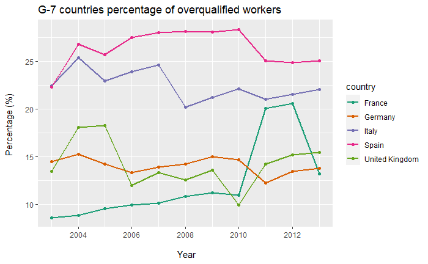

```r
tidy_overqualified_workers %>%
  filter(
    country %in% c("France", "Germany", "Italy", "Spain", "United Kingdom")
  ) %>%
  ggplot() +
  aes(x = year, y = percentage, group = country, colour = country) +
  geom_line(size = 0.75) +
  geom_point(size = 1.5) +
  scale_colour_brewer(palette = "Dark2") +
  # scale_colour_manual(values = cbb_palette) +
  ggtitle("G-7 countries percentage of overqualified workers") +
  labs(
    x = "\n Year",
    y = "Percentage (%) \n"
  )
```

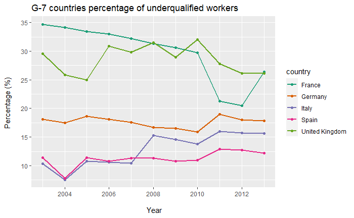

```r
tidy_underqualified_workers %>%
  filter(
    country %in% c("France", "Germany", "Italy", "Spain", "United Kingdom")
  ) %>%
  ggplot() +
  aes(x = year, y = percentage, group = country, colour = country) +
  geom_line(size = 0.75) +
  geom_point(size = 1.5) +
  scale_colour_brewer(palette = "Dark2") +
  # scale_colour_manual(values = cbb_palette) +
  ggtitle("G-7 countries percentage of underqualified workers") +
  labs(
    x = "\n Year",
    y = "Percentage (%) \n"
  )
```

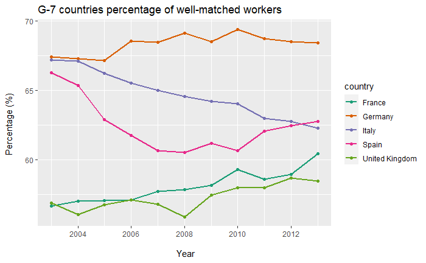

```r
tidy_qualified_workers %>%
  filter(
    country %in% c("France", "Germany", "Italy", "Spain", "United Kingdom")
  ) %>%
  ggplot() +
  aes(x = year, y = percentage, group = country, colour = country) +
  geom_line(size = 0.75) +
  geom_point(size = 1.5) +
  scale_colour_brewer(palette = "Dark2") +
  # scale_colour_manual(values = cbb_palette) +
  ggtitle("G-7 countries percentage of well-matched workers") +
  labs(
    x = "\n Year",
    y = "Percentage (%) \n"
  )
```

Comparison with all countries in Europe

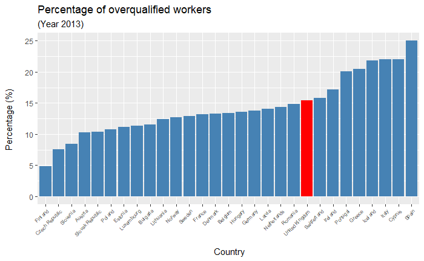

```r
tidy_overqualified_workers %>%
  mutate(year = year(year)) %>%
  filter(
    country != c("Malta"),
    year == 2013
    ) %>%
  ggplot() +
  aes(
    x = reorder(country, percentage),
    y = percentage,
    fill = reorder(country, percentage) == "United Kingdom"
    ) +
  geom_col() +
  scale_fill_manual(values = c('steelblue', 'red'), guide = "none") +
  theme(
    axis.text.x = element_text(size = 6, angle = 45, vjust = 1, hjust = 1)
    ) +
  ggtitle(
    "Percentage of overqualified workers",
    subtitle = "(Year 2013)"
  ) +
  labs(
    x = "\n Country",
    y = "Percentage (%) \n"
  )
```

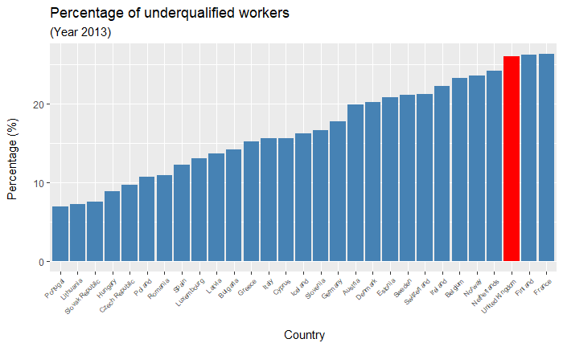

```r
tidy_underqualified_workers %>%
  mutate(year = year(year)) %>%
  filter(
    country != c("Malta"),
    year == 2013
    ) %>%
  ggplot() +
  aes(
    x = reorder(country, percentage),
    y = percentage,
    fill = reorder(country, percentage) == "United Kingdom"
    ) +
  geom_col() +
  scale_fill_manual(values = c('steelblue', 'red'), guide = "none") +
  theme(
    axis.text.x = element_text(size = 6, angle = 45, vjust = 1, hjust = 1)
    ) +
  ggtitle(
    "Percentage of underqualified workers",
    subtitle = "(Year 2013)"
  ) +
  labs(
    x = "\n Country",
    y = "Percentage (%) \n"
  )
```

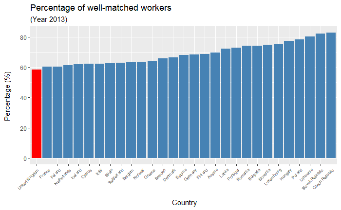

```r
tidy_qualified_workers %>%
  mutate(year = year(year)) %>%
  filter(
    country != c("Malta"),
    year == 2013
    ) %>%
  ggplot() +
  aes(
    x = reorder(country, percentage),
    y = percentage,
    fill = reorder(country, percentage) == "United Kingdom"
    ) +
  geom_col() +
  scale_fill_manual(values = c('steelblue', 'red'), guide = "none") +
  theme(
    axis.text.x = element_text(size = 6, angle = 45, vjust = 1, hjust = 1)
    ) +
  ggtitle(
    "Percentage of well-matched workers",
    subtitle = "(Year 2013)"
  ) +
  labs(
    x = "\n Country",
    y = "Percentage (%) \n"
  )
```

OECD Tertiary Spending Expenditure

Read data

```r
education_expenditure <- read_excel(here("raw_data/OECD_Tertiary_Education_Expenditure.xlsx"))

glimpse(education_expenditure)
```

```
Rows: 1,646
Columns: 8
$ LOCATION     <chr> "AUS", "AUS", "AUS", "AUS", "AUS", "AUS", "AUS", "AUS", "AUS", "AUS", "AUS", "AUS", "AUT", "AUT", "AUT", "AUT", "AUT", "AUT", "AUT", "~
$ INDICATOR    <chr> "EDUPUBEXP", "EDUPUBEXP", "EDUPUBEXP", "EDUPUBEXP", "EDUPUBEXP", "EDUPUBEXP", "EDUPUBEXP", "EDUPUBEXP", "EDUPUBEXP", "EDUPUBEXP", "EDU~
$ SUBJECT      <chr> "TRY", "TRY", "TRY", "TRY", "TRY", "TRY", "TRY", "TRY", "TRY", "TRY", "TRY", "TRY", "TRY", "TRY", "TRY", "TRY", "TRY", "TRY", "TRY", "~
$ MEASURE      <chr> "PC_GDP", "PC_GDP", "PC_GDP", "PC_GDP", "PC_GDP", "PC_GDP", "PC_GDP", "PC_GDP", "PC_GDP", "PC_GDP", "PC_GDP", "PC_GDP", "PC_GDP", "PC_~
$ FREQUENCY    <chr> "A", "A", "A", "A", "A", "A", "A", "A", "A", "A", "A", "A", "A", "A", "A", "A", "A", "A", "A", "A", "A", "A", "A", "A", "A", "A", "A",~
$ TIME         <dbl> 1995, 2000, 2005, 2008, 2009, 2010, 2011, 2012, 2013, 2014, 2015, 2016, 1995, 2000, 2005, 2008, 2009, 2010, 2011, 2012, 2013, 2014, 20~
$ Value        <dbl> NA, 0.746, 0.692, 0.691, 0.737, 0.781, 0.745, 0.721, 0.720, 0.718, 0.769, NA, NA, NA, NA, NA, NA, NA, NA, 1.662, 1.649, 1.615, 1.633, ~
$ `Flag Codes` <chr> "M", NA, NA, NA, NA, NA, NA, NA, NA, NA, NA, "M", "M", "M", "M", "M", "M", "M", "M", NA, NA, NA, NA, "M", "M", "M", NA, NA, NA, NA, NA~
```

Change TIME in datetime format

```r
education_expenditure <- education_expenditure %>%
  mutate(TIME = make_datetime(TIME))
```

```r
education_expenditure %>%
  filter(LOCATION == "GBR")
```

| LOCATION | INDICATOR | SUBJECT | MEASURE | FREQUENCY | TIME | Value | Flag Codes |
| --- | --- | --- | --- | --- | --- | --- | --- |
| GBR | EDUPUBEXP | TRY | PC_GDP | A | 1995-01-01 | NA | M |
| GBR | EDUPUBEXP | TRY | PC_GDP | A | 2000-01-01 | NA | M |
| GBR | EDUPUBEXP | TRY | PC_GDP | A | 2005-01-01 | NA | M |
| GBR | EDUPUBEXP | TRY | PC_GDP | A | 2008-01-01 | NA | M |
| GBR | EDUPUBEXP | TRY | PC_GDP | A | 2009-01-01 | NA | M |
| GBR | EDUPUBEXP | TRY | PC_GDP | A | 2010-01-01 | NA | M |
| GBR | EDUPUBEXP | TRY | PC_GDP | A | 2011-01-01 | NA | M |
| GBR | EDUPUBEXP | TRY | PC_GDP | A | 2012-01-01 | 0.953 | NA |
| GBR | EDUPUBEXP | TRY | PC_GDP | A | 2013-01-01 | 0.983 | NA |
| GBR | EDUPUBEXP | TRY | PC_GDP | A | 2014-01-01 | 0.472 | NA |

[output cut: 26 more lines]

Check for NA’s

```r
education_expenditure %>%
  summarise(across(.cols = everything(),
                   .fns = ~sum(is.na(.x))))
```

| LOCATION | INDICATOR | SUBJECT | MEASURE | FREQUENCY | TIME | Value | Flag Codes |
| --- | --- | --- | --- | --- | --- | --- | --- |
| 0 | 0 | 0 | 0 | 0 | 0 | 548 | 1098 |

```r
education_expenditure %>%
  # distinct(LOCATION)
  # distinct(INDICATOR) # EDUPUBEXP
  # distinct(SUBJECT) # TRY, PRY_NTRY, PRY_TRY
  # distinct(MEASURE) # PC_GDP
  # distinct(FREQUENCY) #A
  distinct(`Flag Codes`) # NA, M
```

| Flag Codes |
| --- |
| M |
| NA |

G-7 countries education expenditure (GDP percentage) TRY : TeRtiarY PRY_NTRY: PRimarY to post-secondary Non-TeRtiarY PRY_TRY: PRimarY to TeRtiarY

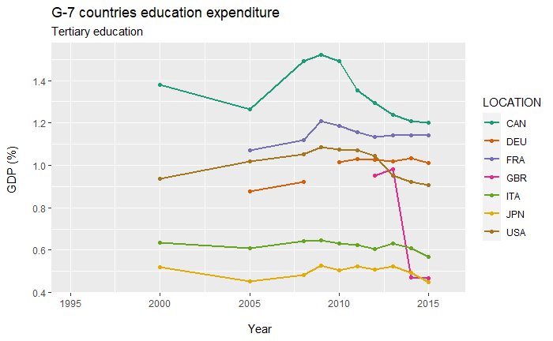

```r
education_expenditure %>%
  select(-c(`Flag Codes`, INDICATOR, FREQUENCY, MEASURE)) %>%
  filter(
    LOCATION %in% c("CAN", "FRA", "DEU", "ITA", "JPN", "USA", "GBR"),
    SUBJECT == "TRY"
    ) %>%
  ggplot() +
  aes(x = TIME, y = Value, colour = LOCATION) +
  geom_line(size = 0.75) +
  geom_point(size = 1.5) +
  scale_colour_brewer(palette = "Dark2") +
  # scale_colour_manual(values = cbb_palette) +
  ggtitle(
    "G-7 countries education expenditure",
    subtitle = "Tertiary education"
  ) +
  labs(
    x = "\n Year",
    y = "GDP (%) \n"
  )
```

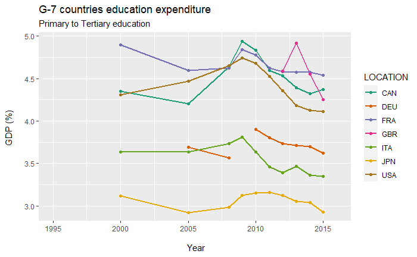

```r
education_expenditure %>%
  select(-c(`Flag Codes`, INDICATOR, FREQUENCY, MEASURE)) %>%
  filter(
    LOCATION %in% c("CAN", "FRA", "DEU", "ITA", "JPN", "USA", "GBR"),
    SUBJECT == "PRY_TRY"
    ) %>%
  ggplot() +
  aes(x = TIME, y = Value, colour = LOCATION) +
  geom_line(size = 0.75) +
  geom_point(size = 1.5) +
  scale_colour_brewer(palette = "Dark2") +
  # scale_colour_manual(values = cbb_palette) +
  ggtitle(
    "G-7 countries education expenditure",
    subtitle = "Primary to Tertiary education"
  ) +
  labs(
    x = "\n Year",
    y = "GDP (%) \n"
  )
```

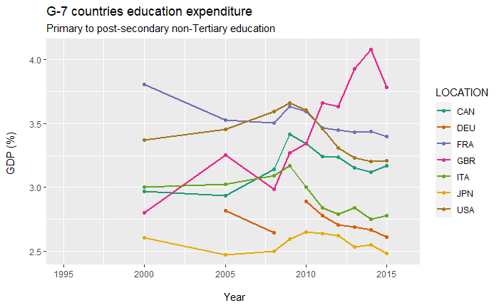

```r
education_expenditure %>%
  select(-c(`Flag Codes`, INDICATOR, FREQUENCY, MEASURE)) %>%
  filter(
    LOCATION %in% c("CAN", "FRA", "DEU", "ITA", "JPN", "USA", "GBR"),
    SUBJECT == "PRY_NTRY"
    ) %>%
  ggplot() +
  aes(x = TIME, y = Value, colour = LOCATION) +
  geom_line(size = 0.75) +
  geom_point(size = 1.5) +
  scale_colour_brewer(palette = "Dark2") +
  # scale_colour_manual(values = cbb_palette) +
  ggtitle(
    "G-7 countries education expenditure",
    subtitle = "Primary to post-secondary non-Tertiary education"
  ) +
  labs(
    x = "\n Year",
    y = "GDP (%) \n"
  )
```

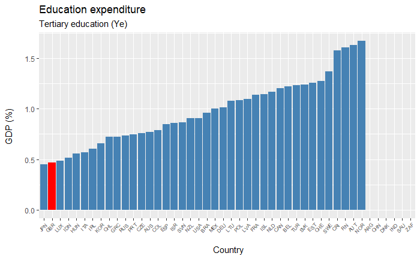

```r
education_expenditure %>%
  mutate(TIME = year(TIME)) %>%
  filter(
    TIME == 2015,
    SUBJECT == "TRY"
    ) %>%
  select(-c(`Flag Codes`, INDICATOR, FREQUENCY, MEASURE, TIME)) %>%
  ggplot() +
  aes(
    x = reorder(LOCATION, Value),
    y = Value,
    fill = reorder(LOCATION, Value) == "GBR"
    ) +
  geom_col() +
  scale_fill_manual(values = c('steelblue', 'red'), guide = "none") +
  theme(
    axis.text.x = element_text(size = 6, angle = 45, vjust = 1, hjust = 1)
  ) +
  ggtitle(
    "Education expenditure",
    subtitle = "Tertiary education (Ye)"
  ) +
  labs(
    x = "\n Country",
    y = "GDP (%) \n"
  )
```

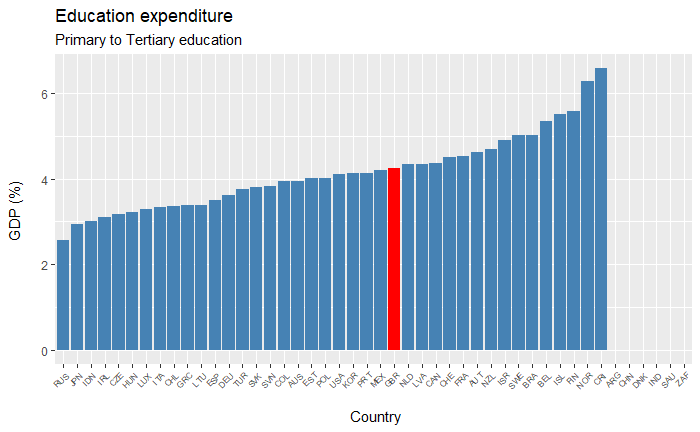

```r
education_expenditure %>%
  mutate(TIME = year(TIME)) %>%
  filter(
    TIME == 2015,
    SUBJECT == "PRY_TRY"
    ) %>%
  select(-c(`Flag Codes`, INDICATOR, FREQUENCY, MEASURE, TIME)) %>%
  ggplot() +
  aes(
    x = reorder(LOCATION, Value),
    y = Value,
    fill = reorder(LOCATION, Value) == "GBR"
    ) +
  geom_col() +
  scale_fill_manual(values = c('steelblue', 'red'), guide = "none") +
  theme(
    axis.text.x = element_text(size = 6, angle = 45, vjust = 1, hjust = 1)
  ) +
  ggtitle(
    "Education expenditure",
    subtitle = "Primary to Tertiary education"
  ) +
  labs(
    x = "\n Country",
    y = "GDP (%) \n"
  )
```

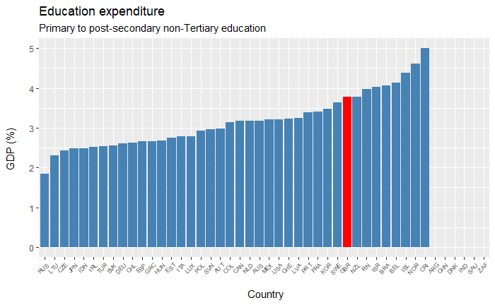

```r
education_expenditure %>%
  mutate(TIME = year(TIME)) %>%
  filter(
    TIME == 2015,
    SUBJECT == "PRY_NTRY"
    ) %>%
  select(-c(`Flag Codes`, INDICATOR, FREQUENCY, MEASURE, TIME)) %>%
  ggplot() +
  aes(
    x = reorder(LOCATION, Value),
    y = Value,
    fill = reorder(LOCATION, Value) == "GBR"
    ) +
  geom_col() +
  scale_fill_manual(values = c('steelblue', 'red'), guide = "none") +
  theme(
    axis.text.x = element_text(size = 6, angle = 45, vjust = 1, hjust = 1)
  ) +
  ggtitle(
    "Education expenditure",
    subtitle = "Primary to post-secondary non-Tertiary education"
  ) +
  labs(
    x = "\n Country",
    y = "GDP (%) \n"
  )
```

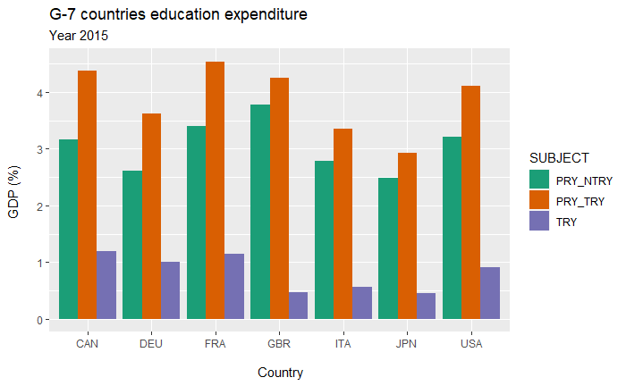

```r
education_expenditure %>%
  mutate(TIME = year(TIME)) %>%
  filter(
    LOCATION %in% c("CAN", "FRA", "DEU", "ITA", "JPN", "USA", "GBR"),
    TIME == 2015
    ) %>%
  select(-c(`Flag Codes`, INDICATOR, FREQUENCY, MEASURE)) %>%
  ggplot() +
  aes(x = LOCATION, y = Value, fill = SUBJECT) +
  geom_col(position = "dodge") +
  scale_fill_brewer(palette = "Dark2") +
  ggtitle(
    "G-7 countries education expenditure",
    subtitle = "Year 2015"
  ) +
  labs(
    x = "\n Country",
    y = "GDP (%) \n"
  )
```

TRY : TeRtiarY PRY_NTRY: PRimarY to post-secondary Non-TeRtiarY PRY_TRY: PRimarY to TeRtiarY

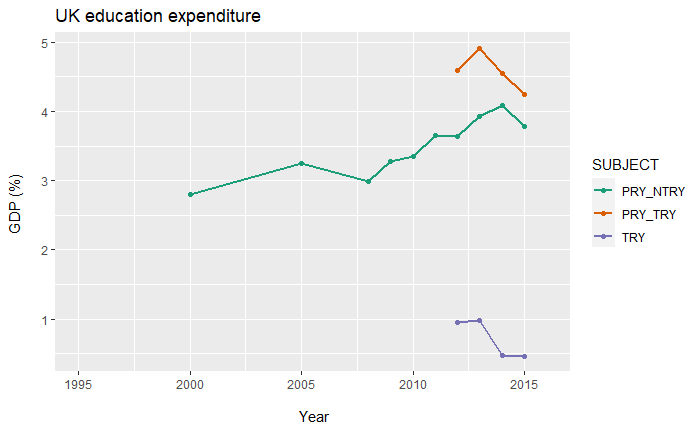

```r
education_expenditure %>%
  select(-c(`Flag Codes`, INDICATOR, FREQUENCY, MEASURE)) %>%
  filter(LOCATION %in% c("GBR")) %>%
  ggplot() +
  aes(x = TIME, y = Value, colour = SUBJECT) +
  geom_line(size = 0.75) +
  geom_point(size = 1.5) +
  scale_colour_brewer(palette = "Dark2") +
  # scale_colour_manual(values = cbb_palette) +
  ggtitle("UK education expenditure") +
  labs(
    x = "\n Year",
    y = "GDP (%) \n"
  )
```

**Multifactor productivity**

Read data

```r
mfp <- read_excel(here("raw_data/Multifactor_Productivity-OECD_Countries.xls"))

glimpse(mfp)
```

```
Rows: 1,261
Columns: 8
$ LOCATION     <chr> "AUS", "AUS", "AUS", "AUS", "AUS", "AUS", "AUS", "AUS", "AUS", "AUS", "AUS", "AUS", "AUS", "AUS", "AUS", "AUS", "AUS", "AUS", "AUS", "~
$ INDICATOR    <chr> "MFP", "MFP", "MFP", "MFP", "MFP", "MFP", "MFP", "MFP", "MFP", "MFP", "MFP", "MFP", "MFP", "MFP", "MFP", "MFP", "MFP", "MFP", "MFP", "~
$ SUBJECT      <chr> "TOT", "TOT", "TOT", "TOT", "TOT", "TOT", "TOT", "TOT", "TOT", "TOT", "TOT", "TOT", "TOT", "TOT", "TOT", "TOT", "TOT", "TOT", "TOT", "~
$ MEASURE      <chr> "AGRWTH", "AGRWTH", "AGRWTH", "AGRWTH", "AGRWTH", "AGRWTH", "AGRWTH", "AGRWTH", "AGRWTH", "AGRWTH", "AGRWTH", "AGRWTH", "AGRWTH", "AGR~
$ FREQUENCY    <chr> "A", "A", "A", "A", "A", "A", "A", "A", "A", "A", "A", "A", "A", "A", "A", "A", "A", "A", "A", "A", "A", "A", "A", "A", "A", "A", "A",~
$ TIME         <dbl> 1985, 1986, 1987, 1988, 1989, 1990, 1991, 1992, 1993, 1994, 1995, 1996, 1997, 1998, 1999, 2000, 2001, 2002, 2003, 2004, 2005, 2006, 20~
$ Value        <dbl> -0.764566, -0.734375, 1.606074, -0.600157, -0.218278, -2.445257, 0.771477, 2.338319, 0.430123, 0.166251, 2.115822, 2.437600, 2.355133,~
$ `Flag Codes` <lgl> NA, NA, NA, NA, NA, NA, NA, NA, NA, NA, NA, NA, NA, NA, NA, NA, NA, NA, NA, NA, NA, NA, NA, NA, NA, NA, NA, NA, NA, NA, NA, NA, NA, NA~
```

Change TIME in datetime format

```r
mfp <- mfp %>%
  mutate(TIME = make_datetime(TIME))
```

Check for NA’s

```r
mfp %>%
  summarise(across(.cols = everything(),
                   .fns = ~sum(is.na(.x))))
```

| LOCATION | INDICATOR | SUBJECT | MEASURE | FREQUENCY | TIME | Value | Flag Codes |
| --- | --- | --- | --- | --- | --- | --- | --- |
| 0 | 0 | 0 | 0 | 0 | 0 | 0 | 1261 |

```r
mfp %>%
  # distinct(LOCATION)
   distinct(INDICATOR) # MFP
```

| INDICATOR |
| --- |
| MFP |

```r
  # distinct(SUBJECT) # TOT
  # distinct(MEASURE) # AGRWTH, IDX2010
  # distinct(FREQUENCY) #A
  # distinct(`Flag Codes`) # NA
```

G-7 countries Multifactor productivity (annual growth rate)

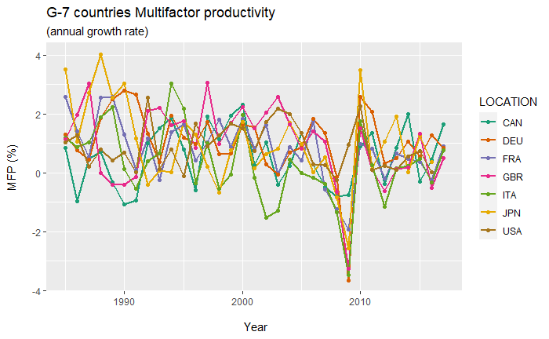

```r
mfp%>%
  select(-c(`Flag Codes`, INDICATOR, FREQUENCY, SUBJECT)) %>%
  filter(
    LOCATION %in% c("CAN", "FRA", "DEU", "ITA", "JPN", "USA", "GBR"),
    MEASURE == "AGRWTH"
  ) %>%
  ggplot() +
  aes(x = TIME, y = Value, colour = LOCATION) +
  geom_line(size = 0.75) +
  geom_point(size = 1.5) +
  scale_colour_brewer(palette = "Dark2") +
  # scale_colour_manual(values = cbb_palette) +
  ggtitle(
    "G-7 countries Multifactor productivity",
    subtitle = "(annual growth rate)"
  ) +
  labs(
    x = "\n Year",
    y = "MFP (%)\n"
  )
```

```r
NA
```

G-7 countries Multifactor productivity (index 2010)

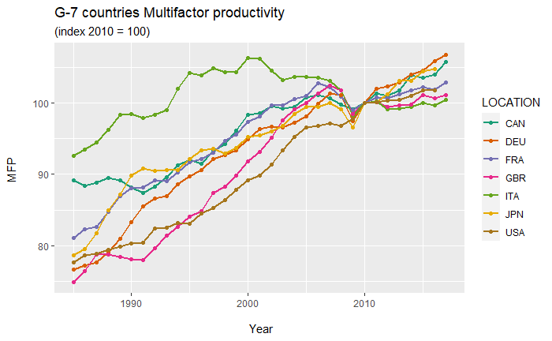

```r
mfp%>%
  select(-c(`Flag Codes`, INDICATOR, FREQUENCY, SUBJECT)) %>%
  filter(
    LOCATION %in% c("CAN", "FRA", "DEU", "ITA", "JPN", "USA", "GBR"),
    MEASURE == "IDX2010"
  ) %>%
  ggplot() +
  aes(x = TIME, y = Value, colour = LOCATION) +
  geom_line(size = 0.75) +
  geom_point(size = 1.5) +
  scale_colour_brewer(palette = "Dark2") +
  # scale_colour_manual(values = cbb_palette) +
  ggtitle(
    "G-7 countries Multifactor productivity",
    subtitle = "(index 2010 = 100)"
  ) +
  labs(
    x = "\n Year",
    y = "MFP \n"
  )
```

```r
NA
```